# Project: Investigate a Dataset - FBI Gun Data

- Introduction
- Data Wrangling
- Exploratory Data Analysis
- Conclusions

## Introduction

### Dataset Description

#### gun_data.csv

This data is the number of firearm checks by month, state, and type that are called into the FBI's National Instant Criminal Background Check System. Gun shops use the system to verify customers' eligibility for buying guns.

One big point to note is that these numbers represent gun background checks, not sales, and a 1:1 correlation cannot be made between the two.

The main columns included in the dataset are:

- month - The year and month data was collected for
- state - The US state data is being collected on
- totals - The total number of background checks for that month and state

The totals are then broken down into both type of check that is being done and the gun type the check is being done for. The types of checks are:

- Non-Specified - Checks initiated by an officially-licensed Federal Firearms Licensee (FFL) or criminal justice/law enforcement agency prior to the issuance of a firearm-related permit or transfer.
- Pre-Pawn - Checks requested by an officially-licensed FFL on prospective firearm transferees seeking to pledge or pawn a firearm as security for the payment or repayment of money, prior to actually pledging or pawning the firearm.
- Redemption - Checks requested by an officially-licensed FFL on prospective firearm transferees attempting to regain possession of a firearm after pledging or pawning a firearm as security at a pawn shop.
- Returned/Disposition - Checks requested by criminal justice/law enforcement agencies prior to returning a firearm in its possession to the respective transferee, to ensure the individual is not prohibited.
- Rentals - Checks requested by an officially-licensed FFL on prospective firearm transferees attempting to possess a firearm when the firearm is loaned or rented for use off the premises of the business.
- Private Sale - Checks requested by an officially-licensed FFL on prospective firearm transferees attempting to possess a firearm from a private party seller who is not an officially-licensed FFL.
- Return to Seller - Checks requested by an officially-licensed FFL on prospective firearm transferees attempting to possess a firearm from a private party seller who is not an officially-licensed FFL.

And the types of guns are:

- Handgun - Any firearm which has a short stock and is designed to be held and fired by the use of a single hand; and (b) any combination of parts from which a firearm described in paragraph (a) can be assembled.
- Long Gun - A weapon designed or redesigned, made or remade, and intended to be fired from the shoulder, and designed or redesigned and made or remade to use the energy of the explosive in (a) a fixed metallic cartridge to fire a single projectile through a rifled bore for each single pull of the trigger; or (b) a fixed shotgun shell to fire through a smooth bore either a number of ball shot or a single projectile for each single pull of the trigger.
- Other - Refers to frames, receivers, and other firearms that are neither handguns nor long guns (rifles or shotguns), such as firearms having a pistol grip that expel a shotgun shell, or National Firearms Act firearms, including silencers.

#### US_Census_Data.csv

This is US Census Data straight from the United States Census Bureau. It contains several census variables broken out by state. While no direct link to the gun_data.csv, both data sets are provided on a state level meaning the census data can supplement the gun data for additional investigation.

The data is organized with the state names as the columns, and the census variables as rows.

### Question(s) for Analysis

#### Question 1:

Does the sitting President's political party, have an effect on the number of background checks being run for guns?

#### Question 2:

Are there any state demographics that effect the number of background checks being run for guns?

```python
import pandas as pd
import numpy as np
```

## Data Wrangling

### General Properties

I'll start with the gun data and I want to get an idea of what the data looks like. So, I am going to look at the first few rows of that DataFrame

```python
nics_df = pd.read_csv('Database_Ncis_and_Census_data/gun_data.csv')
nics_df.head()
```

|  | month | state | permit | permit_recheck | handgun | long_gun | other | multiple | admin | prepawn_handgun | ... | returned_other | rentals_handgun | rentals_long_gun | private_sale_handgun | private_sale_long_gun | private_sale_other | return_to_seller_handgun | return_to_seller_long_gun | return_to_seller_other | totals |
| --- | --- | --- | --- | --- | --- | --- | --- | --- | --- | --- | --- | --- | --- | --- | --- | --- | --- | --- | --- | --- | --- |
| 0 | 2017-09 | Alabama | 16717.0 | 0.0 | 5734.0 | 6320.0 | 221.0 | 317 | 0.0 | 15.0 | ... | 0.0 | 0.0 | 0.0 | 9.0 | 16.0 | 3.0 | 0.0 | 0.0 | 3.0 | 32019 |
| 1 | 2017-09 | Alaska | 209.0 | 2.0 | 2320.0 | 2930.0 | 219.0 | 160 | 0.0 | 5.0 | ... | 0.0 | 0.0 | 0.0 | 17.0 | 24.0 | 1.0 | 0.0 | 0.0 | 0.0 | 6303 |
| 2 | 2017-09 | Arizona | 5069.0 | 382.0 | 11063.0 | 7946.0 | 920.0 | 631 | 0.0 | 13.0 | ... | 0.0 | 0.0 | 0.0 | 38.0 | 12.0 | 2.0 | 0.0 | 0.0 | 0.0 | 28394 |
| 3 | 2017-09 | Arkansas | 2935.0 | 632.0 | 4347.0 | 6063.0 | 165.0 | 366 | 51.0 | 12.0 | ... | 0.0 | 0.0 | 0.0 | 13.0 | 23.0 | 0.0 | 0.0 | 2.0 | 1.0 | 17747 |
| 4 | 2017-09 | California | 57839.0 | 0.0 | 37165.0 | 24581.0 | 2984.0 | 0 | 0.0 | 0.0 | ... | 0.0 | 0.0 | 0.0 | 0.0 | 0.0 | 0.0 | 0.0 | 0.0 | 0.0 | 123506 |

5 rows × 27 columns

Now that I've seen what the data looks like, I want to see if there are any nulls

```python
nics_df.info()
```

```
<class 'pandas.core.frame.DataFrame'>
RangeIndex: 12485 entries, 0 to 12484
Data columns (total 27 columns):
 #   Column                     Non-Null Count  Dtype
---  ------                     --------------  -----
 0   month                      12485 non-null  object
 1   state                      12485 non-null  object
 2   permit                     12461 non-null  float64
 3   permit_recheck             1100 non-null   float64
 4   handgun                    12465 non-null  float64
 5   long_gun                   12466 non-null  float64
 6   other                      5500 non-null   float64
 7   multiple                   12485 non-null  int64
 8   admin                      12462 non-null  float64
 9   prepawn_handgun            10542 non-null  float64
```

[output cut: 19 more lines]

And to get a better idea of the ranges I'm working with, a look at some quick descriptive statistics on the data points

```python
nics_df.describe()
```

|  | permit | permit_recheck | handgun | long_gun | other | multiple | admin | prepawn_handgun | prepawn_long_gun | prepawn_other | ... | returned_other | rentals_handgun | rentals_long_gun | private_sale_handgun | private_sale_long_gun | private_sale_other | return_to_seller_handgun | return_to_seller_long_gun | return_to_seller_other | totals |
| --- | --- | --- | --- | --- | --- | --- | --- | --- | --- | --- | --- | --- | --- | --- | --- | --- | --- | --- | --- | --- | --- |
| count | 12461.000000 | 1100.000000 | 12465.000000 | 12466.000000 | 5500.000000 | 12485.000000 | 12462.000000 | 10542.000000 | 10540.000000 | 5115.000000 | ... | 1815.000000 | 990.000000 | 825.000000 | 2750.000000 | 2750.000000 | 2750.000000 | 2475.000000 | 2750.000000 | 2255.000000 | 12485.000000 |
| mean | 6413.629404 | 1165.956364 | 5940.881107 | 7810.847585 | 360.471636 | 268.603364 | 58.898090 | 4.828021 | 7.834156 | 0.165591 | ... | 1.027548 | 0.076768 | 0.087273 | 14.936000 | 11.602909 | 1.030182 | 0.402020 | 0.441818 | 0.105987 | 21595.725911 |
| std | 23752.338269 | 9224.200609 | 8618.584060 | 9309.846140 | 1349.478273 | 783.185073 | 604.814818 | 10.907756 | 16.468028 | 1.057105 | ... | 4.386296 | 0.634503 | 0.671649 | 71.216021 | 54.253090 | 4.467843 | 1.446568 | 1.528223 | 0.427363 | 32591.418387 |
| min | 0.000000 | 0.000000 | 0.000000 | 0.000000 | 0.000000 | 0.000000 | 0.000000 | 0.000000 | 0.000000 | 0.000000 | ... | 0.000000 | 0.000000 | 0.000000 | 0.000000 | 0.000000 | 0.000000 | 0.000000 | 0.000000 | 0.000000 | 0.000000 |
| 25% | 0.000000 | 0.000000 | 865.000000 | 2078.250000 | 17.000000 | 15.000000 | 0.000000 | 0.000000 | 0.000000 | 0.000000 | ... | 0.000000 | 0.000000 | 0.000000 | 0.000000 | 0.000000 | 0.000000 | 0.000000 | 0.000000 | 0.000000 | 4638.000000 |
| 50% | 518.000000 | 0.000000 | 3059.000000 | 5122.000000 | 121.000000 | 125.000000 | 0.000000 | 0.000000 | 1.000000 | 0.000000 | ... | 0.000000 | 0.000000 | 0.000000 | 0.000000 | 0.000000 | 0.000000 | 0.000000 | 0.000000 | 0.000000 | 12399.000000 |
| 75% | 4272.000000 | 0.000000 | 7280.000000 | 10380.750000 | 354.000000 | 301.000000 | 0.000000 | 5.000000 | 8.000000 | 0.000000 | ... | 0.000000 | 0.000000 | 0.000000 | 2.000000 | 4.000000 | 0.000000 | 0.000000 | 0.000000 | 0.000000 | 25453.000000 |
| max | 522188.000000 | 116681.000000 | 107224.000000 | 108058.000000 | 77929.000000 | 38907.000000 | 28083.000000 | 164.000000 | 269.000000 | 49.000000 | ... | 64.000000 | 12.000000 | 12.000000 | 1017.000000 | 777.000000 | 71.000000 | 28.000000 | 17.000000 | 4.000000 | 541978.000000 |

8 rows × 25 columns

I also need to take a look at the census data.

```python
census_df = pd.read_csv('Database_Ncis_and_Census_data/US_Census_Data.csv')
census_df.head()
```

|  | Fact | Fact Note | Alabama | Alaska | Arizona | Arkansas | California | Colorado | Connecticut | Delaware | ... | South Dakota | Tennessee | Texas | Utah | Vermont | Virginia | Washington | West Virginia | Wisconsin | Wyoming |
| --- | --- | --- | --- | --- | --- | --- | --- | --- | --- | --- | --- | --- | --- | --- | --- | --- | --- | --- | --- | --- | --- |
| 0 | Population estimates, July 1, 2016, (V2016) | NaN | 4,863,300 | 741,894 | 6,931,071 | 2,988,248 | 39,250,017 | 5,540,545 | 3,576,452 | 952,065 | ... | 865454 | 6651194 | 27,862,596 | 3,051,217 | 624,594 | 8,411,808 | 7,288,000 | 1,831,102 | 5,778,708 | 585,501 |
| 1 | Population estimates base, April 1, 2010, (V2... | NaN | 4,780,131 | 710,249 | 6,392,301 | 2,916,025 | 37,254,522 | 5,029,324 | 3,574,114 | 897,936 | ... | 814195 | 6346298 | 25,146,100 | 2,763,888 | 625,741 | 8,001,041 | 6,724,545 | 1,853,011 | 5,687,289 | 563,767 |
| 2 | Population, percent change - April 1, 2010 (es... | NaN | 1.70% | 4.50% | 8.40% | 2.50% | 5.40% | 10.20% | 0.10% | 6.00% | ... | 0.063 | 0.048 | 10.80% | 10.40% | -0.20% | 5.10% | 8.40% | -1.20% | 1.60% | 3.90% |
| 3 | Population, Census, April 1, 2010 | NaN | 4,779,736 | 710,231 | 6,392,017 | 2,915,918 | 37,253,956 | 5,029,196 | 3,574,097 | 897,934 | ... | 814180 | 6346105 | 25,145,561 | 2,763,885 | 625,741 | 8,001,024 | 6,724,540 | 1,852,994 | 5,686,986 | 563,626 |
| 4 | Persons under 5 years, percent, July 1, 2016, ... | NaN | 6.00% | 7.30% | 6.30% | 6.40% | 6.30% | 6.10% | 5.20% | 5.80% | ... | 0.071 | 0.061 | 7.20% | 8.30% | 4.90% | 6.10% | 6.20% | 5.50% | 5.80% | 6.50% |

5 rows × 52 columns

Looking at that, there are null values in the 'Fact Note' column I'll have to deal with, and it seems the 'Fact' column has a lot of text in it that I will need to handle

```python
census_df.info()
```

```
<class 'pandas.core.frame.DataFrame'>
RangeIndex: 85 entries, 0 to 84
Data columns (total 52 columns):
 #   Column          Non-Null Count  Dtype
---  ------          --------------  -----
 0   Fact            80 non-null     object
 1   Fact Note       28 non-null     object
 2   Alabama         65 non-null     object
 3   Alaska          65 non-null     object
 4   Arizona         65 non-null     object
 5   Arkansas        65 non-null     object
 6   California      65 non-null     object
 7   Colorado        65 non-null     object
 8   Connecticut     65 non-null     object
 9   Delaware        65 non-null     object
```

[output cut: 44 more lines]

All of the states have exactly 65 non-null values, but the 'Fact' column has 80. This makes me wonder if there are some rows with completely null values in them. This is something I will need to look into when cleaning the data.

### Data Cleaning

According to the nics_df.info(), there are null values in all count values besides multiple and total. My intuition would be that the nulls are all meant to be zeroes, but to make sure, I will add all the columns up (excluding the nulls) and compare them to the total. If they are equal, then the nulls would be zero.

I'll start off by replacing all the nulls with zeros, then confirming there are no nulls.

```python
nics_zeros_df = nics_df.fillna(0)
nics_zeros_df.isnull().sum().sum()
```

```
0
```

I will then create a calculate total column called calc_total. It will be the sum of all types of background checks.

```python
nics_zeros_df['calc_total'] = nics_df.iloc[:, 2:26].sum(axis=1)
nics_zeros_df.head()
```

|  | month | state | permit | permit_recheck | handgun | long_gun | other | multiple | admin | prepawn_handgun | ... | rentals_handgun | rentals_long_gun | private_sale_handgun | private_sale_long_gun | private_sale_other | return_to_seller_handgun | return_to_seller_long_gun | return_to_seller_other | totals | calc_total |
| --- | --- | --- | --- | --- | --- | --- | --- | --- | --- | --- | --- | --- | --- | --- | --- | --- | --- | --- | --- | --- | --- |
| 0 | 2017-09 | Alabama | 16717.0 | 0.0 | 5734.0 | 6320.0 | 221.0 | 317 | 0.0 | 15.0 | ... | 0.0 | 0.0 | 9.0 | 16.0 | 3.0 | 0.0 | 0.0 | 3.0 | 32019 | 32019.0 |
| 1 | 2017-09 | Alaska | 209.0 | 2.0 | 2320.0 | 2930.0 | 219.0 | 160 | 0.0 | 5.0 | ... | 0.0 | 0.0 | 17.0 | 24.0 | 1.0 | 0.0 | 0.0 | 0.0 | 6303 | 6303.0 |
| 2 | 2017-09 | Arizona | 5069.0 | 382.0 | 11063.0 | 7946.0 | 920.0 | 631 | 0.0 | 13.0 | ... | 0.0 | 0.0 | 38.0 | 12.0 | 2.0 | 0.0 | 0.0 | 0.0 | 28394 | 28394.0 |
| 3 | 2017-09 | Arkansas | 2935.0 | 632.0 | 4347.0 | 6063.0 | 165.0 | 366 | 51.0 | 12.0 | ... | 0.0 | 0.0 | 13.0 | 23.0 | 0.0 | 0.0 | 2.0 | 1.0 | 17747 | 17747.0 |
| 4 | 2017-09 | California | 57839.0 | 0.0 | 37165.0 | 24581.0 | 2984.0 | 0 | 0.0 | 0.0 | ... | 0.0 | 0.0 | 0.0 | 0.0 | 0.0 | 0.0 | 0.0 | 0.0 | 123506 | 123506.0 |

5 rows × 28 columns

Now I will search for any rows where the totals and calc_total columns are not equal

```python
nics_zeros_df.query('totals != calc_total').count()[0]
```

```
0
```

Since there are 0 such rows, I know the nulls reprensent zeros, and can be updated on the main DataFrame

```python
nics_df.fillna(0, inplace = True)
```

Next, to make it easier to group data by time, I'll convert the month column into a datetime type

```python
nics_df['month'] = pd.to_datetime(nics_df['month'])
nics_df.info()
```

```
<class 'pandas.core.frame.DataFrame'>
RangeIndex: 12485 entries, 0 to 12484
Data columns (total 27 columns):
 #   Column                     Non-Null Count  Dtype
---  ------                     --------------  -----
 0   month                      12485 non-null  datetime64[ns]
 1   state                      12485 non-null  object
 2   permit                     12485 non-null  float64
 3   permit_recheck             12485 non-null  float64
 4   handgun                    12485 non-null  float64
 5   long_gun                   12485 non-null  float64
 6   other                      12485 non-null  float64
 7   multiple                   12485 non-null  int64
 8   admin                      12485 non-null  float64
 9   prepawn_handgun            12485 non-null  float64
```

[output cut: 19 more lines]

Since I am looking at the political party of sitting Presidents, I need to create a column that lists out the President's political party during each data points time period, so I need to find out what time period I am looking at.

```python
nics_df['month'].describe(datetime_is_numeric=True)
```

```
count                            12485
mean     2008-03-31 23:47:18.766519808
min                1998-11-01 00:00:00
25%                2003-07-01 00:00:00
50%                2008-04-01 00:00:00
75%                2013-01-01 00:00:00
max                2017-09-01 00:00:00
Name: month, dtype: object
```

Looking at the min and max of the month column, the dates range from November 1998 through September 2017.

I now need to create a function that looks at the date of the row, then, in a new column titled pres_party, outputs either Republican or Democrat.

```python
def presidential_party(row):
    if row >= pd.to_datetime('2017-01-20'):
        return 'Republican'
    elif row >= pd.to_datetime('2009-01-20'):
        return 'Democrat'
    elif row >= pd.to_datetime('2001-01-20'):
        return 'Republican'
    elif row >= pd.to_datetime('1993-01-20'):
        return 'Democrat'

nics_df['pres_party'] = nics_df['month'].apply(presidential_party)
nics_df.head()
```

|  | month | state | permit | permit_recheck | handgun | long_gun | other | multiple | admin | prepawn_handgun | ... | rentals_handgun | rentals_long_gun | private_sale_handgun | private_sale_long_gun | private_sale_other | return_to_seller_handgun | return_to_seller_long_gun | return_to_seller_other | totals | pres_party |
| --- | --- | --- | --- | --- | --- | --- | --- | --- | --- | --- | --- | --- | --- | --- | --- | --- | --- | --- | --- | --- | --- |
| 0 | 2017-09-01 | Alabama | 16717.0 | 0.0 | 5734.0 | 6320.0 | 221.0 | 317 | 0.0 | 15.0 | ... | 0.0 | 0.0 | 9.0 | 16.0 | 3.0 | 0.0 | 0.0 | 3.0 | 32019 | Republican |
| 1 | 2017-09-01 | Alaska | 209.0 | 2.0 | 2320.0 | 2930.0 | 219.0 | 160 | 0.0 | 5.0 | ... | 0.0 | 0.0 | 17.0 | 24.0 | 1.0 | 0.0 | 0.0 | 0.0 | 6303 | Republican |
| 2 | 2017-09-01 | Arizona | 5069.0 | 382.0 | 11063.0 | 7946.0 | 920.0 | 631 | 0.0 | 13.0 | ... | 0.0 | 0.0 | 38.0 | 12.0 | 2.0 | 0.0 | 0.0 | 0.0 | 28394 | Republican |
| 3 | 2017-09-01 | Arkansas | 2935.0 | 632.0 | 4347.0 | 6063.0 | 165.0 | 366 | 51.0 | 12.0 | ... | 0.0 | 0.0 | 13.0 | 23.0 | 0.0 | 0.0 | 2.0 | 1.0 | 17747 | Republican |
| 4 | 2017-09-01 | California | 57839.0 | 0.0 | 37165.0 | 24581.0 | 2984.0 | 0 | 0.0 | 0.0 | ... | 0.0 | 0.0 | 0.0 | 0.0 | 0.0 | 0.0 | 0.0 | 0.0 | 123506 | Republican |

5 rows × 28 columns

In order to optimize things a bit, I'll change the dtype of the numbers to be int32...

```python
for col in nics_df.iloc[:, 2:27].columns.tolist():
    nics_df[col] = nics_df[col].astype('int32')
```

and the state and pres_party columns to the category type.

```python
nics_df = nics_df.astype({'state': 'category', 'pres_party': 'category'})

nics_df.info()
```

```
<class 'pandas.core.frame.DataFrame'>
RangeIndex: 12485 entries, 0 to 12484
Data columns (total 28 columns):
 #   Column                     Non-Null Count  Dtype
---  ------                     --------------  -----
 0   month                      12485 non-null  datetime64[ns]
 1   state                      12485 non-null  category
 2   permit                     12485 non-null  int32
 3   permit_recheck             12485 non-null  int32
 4   handgun                    12485 non-null  int32
 5   long_gun                   12485 non-null  int32
 6   other                      12485 non-null  int32
 7   multiple                   12485 non-null  int32
 8   admin                      12485 non-null  int32
 9   prepawn_handgun            12485 non-null  int32
```

[output cut: 20 more lines]

Moving on to the Census data, because of the null values, I was suspicious that there might be some wonky rows. So, since I already looked at the first few rows, I'll check the last few to see if there is anything there.

```python
census_df.tail()
```

|  | Fact | Fact Note | Alabama | Alaska | Arizona | Arkansas | California | Colorado | Connecticut | Delaware | ... | South Dakota | Tennessee | Texas | Utah | Vermont | Virginia | Washington | West Virginia | Wisconsin | Wyoming |
| --- | --- | --- | --- | --- | --- | --- | --- | --- | --- | --- | --- | --- | --- | --- | --- | --- | --- | --- | --- | --- | --- |
| 80 | FN | Footnote on this item in place of data | NaN | NaN | NaN | NaN | NaN | NaN | NaN | NaN | ... | NaN | NaN | NaN | NaN | NaN | NaN | NaN | NaN | NaN | NaN |
| 81 | NaN | Not available | NaN | NaN | NaN | NaN | NaN | NaN | NaN | NaN | ... | NaN | NaN | NaN | NaN | NaN | NaN | NaN | NaN | NaN | NaN |
| 82 | S | Suppressed; does not meet publication standards | NaN | NaN | NaN | NaN | NaN | NaN | NaN | NaN | ... | NaN | NaN | NaN | NaN | NaN | NaN | NaN | NaN | NaN | NaN |
| 83 | X | Not applicable | NaN | NaN | NaN | NaN | NaN | NaN | NaN | NaN | ... | NaN | NaN | NaN | NaN | NaN | NaN | NaN | NaN | NaN | NaN |
| 84 | Z | Value greater than zero but less than half uni... | NaN | NaN | NaN | NaN | NaN | NaN | NaN | NaN | ... | NaN | NaN | NaN | NaN | NaN | NaN | NaN | NaN | NaN | NaN |

5 rows × 52 columns

Well it looks like there are footnotes at the bottom of the data, but the question is how many are there. I'll look at the last 25 rows of it to see where the footnotes end.

```python
census_df.tail(25)
```

|  | Fact | Fact Note | Alabama | Alaska | Arizona | Arkansas | California | Colorado | Connecticut | Delaware | ... | South Dakota | Tennessee | Texas | Utah | Vermont | Virginia | Washington | West Virginia | Wisconsin | Wyoming |
| --- | --- | --- | --- | --- | --- | --- | --- | --- | --- | --- | --- | --- | --- | --- | --- | --- | --- | --- | --- | --- | --- |
| 60 | Veteran-owned firms, 2012 | NaN | 41,943 | 7,953 | 46,780 | 25,915 | 252,377 | 51,722 | 31,056 | 7,206 | ... | 8604 | 59379 | 213,590 | 18,754 | 8,237 | 76,434 | 49,331 | 12,912 | 39,830 | 6,470 |
| 61 | Nonveteran-owned firms, 2012 | NaN | 316,984 | 56,091 | 427,582 | 192,988 | 3,176,341 | 469,524 | 281,182 | 60,318 | ... | 66219 | 469392 | 2,057,218 | 219,807 | 63,317 | 548,439 | 461,401 | 94,960 | 370,755 | 51,353 |
| 62 | Population per square mile, 2010 | NaN | 94.4 | 1.2 | 56.3 | 56 | 239.1 | 48.5 | 738.1 | 460.8 | ... | 10.7 | 153.9 | 96.3 | 33.6 | 67.9 | 202.6 | 101.2 | 77.1 | 105 | 5.8 |
| 63 | Land area in square miles, 2010 | NaN | 50,645.33 | 570,640.95 | 113,594.08 | 52,035.48 | 155,779.22 | 103,641.89 | 4,842.36 | 1,948.54 | ... | 75811 | 41234.9 | 261,231.71 | 82,169.62 | 9,216.66 | 39,490.09 | 66,455.52 | 24,038.21 | 54,157.80 | 97,093.14 |
| 64 | FIPS Code | NaN | "01" | "02" | "04" | "05" | "06" | "08" | "09" | "10" | ... | "46" | "47" | "48" | "49" | "50" | "51" | "53" | "54" | "55" | "56" |
| 65 | NaN | NaN | NaN | NaN | NaN | NaN | NaN | NaN | NaN | NaN | ... | NaN | NaN | NaN | NaN | NaN | NaN | NaN | NaN | NaN | NaN |
| 66 | NOTE: FIPS Code values are enclosed in quotes ... | NaN | NaN | NaN | NaN | NaN | NaN | NaN | NaN | NaN | ... | NaN | NaN | NaN | NaN | NaN | NaN | NaN | NaN | NaN | NaN |
| 67 | NaN | NaN | NaN | NaN | NaN | NaN | NaN | NaN | NaN | NaN | ... | NaN | NaN | NaN | NaN | NaN | NaN | NaN | NaN | NaN | NaN |
| 68 | Value Notes | NaN | NaN | NaN | NaN | NaN | NaN | NaN | NaN | NaN | ... | NaN | NaN | NaN | NaN | NaN | NaN | NaN | NaN | NaN | NaN |
| 69 | 1 | Includes data not distributed by county. | NaN | NaN | NaN | NaN | NaN | NaN | NaN | NaN | ... | NaN | NaN | NaN | NaN | NaN | NaN | NaN | NaN | NaN | NaN |
| 70 | NaN | NaN | NaN | NaN | NaN | NaN | NaN | NaN | NaN | NaN | ... | NaN | NaN | NaN | NaN | NaN | NaN | NaN | NaN | NaN | NaN |
| 71 | Fact Notes | NaN | NaN | NaN | NaN | NaN | NaN | NaN | NaN | NaN | ... | NaN | NaN | NaN | NaN | NaN | NaN | NaN | NaN | NaN | NaN |
| 72 | (a) | Includes persons reporting only one race | NaN | NaN | NaN | NaN | NaN | NaN | NaN | NaN | ... | NaN | NaN | NaN | NaN | NaN | NaN | NaN | NaN | NaN | NaN |
| 73 | (b) | Hispanics may be of any race, so also are incl... | NaN | NaN | NaN | NaN | NaN | NaN | NaN | NaN | ... | NaN | NaN | NaN | NaN | NaN | NaN | NaN | NaN | NaN | NaN |
| 74 | (c) | Economic Census - Puerto Rico data are not com... | NaN | NaN | NaN | NaN | NaN | NaN | NaN | NaN | ... | NaN | NaN | NaN | NaN | NaN | NaN | NaN | NaN | NaN | NaN |
| 75 | NaN | NaN | NaN | NaN | NaN | NaN | NaN | NaN | NaN | NaN | ... | NaN | NaN | NaN | NaN | NaN | NaN | NaN | NaN | NaN | NaN |
| 76 | Value Flags | NaN | NaN | NaN | NaN | NaN | NaN | NaN | NaN | NaN | ... | NaN | NaN | NaN | NaN | NaN | NaN | NaN | NaN | NaN | NaN |
| 77 | - | Either no or too few sample observations were ... | NaN | NaN | NaN | NaN | NaN | NaN | NaN | NaN | ... | NaN | NaN | NaN | NaN | NaN | NaN | NaN | NaN | NaN | NaN |
| 78 | D | Suppressed to avoid disclosure of confidential... | NaN | NaN | NaN | NaN | NaN | NaN | NaN | NaN | ... | NaN | NaN | NaN | NaN | NaN | NaN | NaN | NaN | NaN | NaN |
| 79 | F | Fewer than 25 firms | NaN | NaN | NaN | NaN | NaN | NaN | NaN | NaN | ... | NaN | NaN | NaN | NaN | NaN | NaN | NaN | NaN | NaN | NaN |
| 80 | FN | Footnote on this item in place of data | NaN | NaN | NaN | NaN | NaN | NaN | NaN | NaN | ... | NaN | NaN | NaN | NaN | NaN | NaN | NaN | NaN | NaN | NaN |
| 81 | NaN | Not available | NaN | NaN | NaN | NaN | NaN | NaN | NaN | NaN | ... | NaN | NaN | NaN | NaN | NaN | NaN | NaN | NaN | NaN | NaN |
| 82 | S | Suppressed; does not meet publication standards | NaN | NaN | NaN | NaN | NaN | NaN | NaN | NaN | ... | NaN | NaN | NaN | NaN | NaN | NaN | NaN | NaN | NaN | NaN |
| 83 | X | Not applicable | NaN | NaN | NaN | NaN | NaN | NaN | NaN | NaN | ... | NaN | NaN | NaN | NaN | NaN | NaN | NaN | NaN | NaN | NaN |
| 84 | Z | Value greater than zero but less than half uni... | NaN | NaN | NaN | NaN | NaN | NaN | NaN | NaN | ... | NaN | NaN | NaN | NaN | NaN | NaN | NaN | NaN | NaN | NaN |

25 rows × 52 columns

It looks like the data ends on row 64, with row 65 being a null. So I will need to drop row 65 and below to loose all the footnotes.

```python
census_df = census_df[:-20]
census_df['Fact'].tail()
```

```
60           Veteran-owned firms, 2012
61        Nonveteran-owned firms, 2012
62    Population per square mile, 2010
63     Land area in square miles, 2010
64                           FIPS Code
Name: Fact, dtype: object
```

I have a feeling that the 'Fact Note' column is related to the footnotes. If that's the case, I'll end up wanting to drop that column as well. So I'm going to look at the values in the 'Fact Note' column to see what is in there.

```python
census_df['Fact Note'].unique()
```

```
array([nan, '(a)', '(b)', '(c)',
       'Includes data not distributed by county.'], dtype=object)
```

I see the (a), (b), and (c) markers that were present in the footnote information, so it appears I was correct in these being related. I can now drop this column from the DataFrame.

```python
census_df.drop('Fact Note', axis=1, inplace=True)
```

With unneccessary columns and rows gone, I want to look at the 'Fact' column. While it is information I need, it is identifying the information that is in the rows and should be labeling the data, not data itself. Because of this, I am going to change it to be the index of the rows

```python
census_df.set_index('Fact', inplace=True)
```

Now, to better match the layout of the gun data, and to allow for setting proper dtypes on the data, I am going to transpose the data to have the states as the index and the facts as the columns.

```python
census_df = census_df.transpose()
census_df.head()
```

| Fact | Population estimates, July 1, 2016, (V2016) | Population estimates base, April 1, 2010, (V2016) | Population, percent change - April 1, 2010 (estimates base) to July 1, 2016, (V2016) | Population, Census, April 1, 2010 | Persons under 5 years, percent, July 1, 2016, (V2016) | Persons under 5 years, percent, April 1, 2010 | Persons under 18 years, percent, July 1, 2016, (V2016) | Persons under 18 years, percent, April 1, 2010 | Persons 65 years and over, percent, July 1, 2016, (V2016) | Persons 65 years and over, percent, April 1, 2010 | ... | All firms, 2012 | Men-owned firms, 2012 | Women-owned firms, 2012 | Minority-owned firms, 2012 | Nonminority-owned firms, 2012 | Veteran-owned firms, 2012 | Nonveteran-owned firms, 2012 | Population per square mile, 2010 | Land area in square miles, 2010 | FIPS Code |
| --- | --- | --- | --- | --- | --- | --- | --- | --- | --- | --- | --- | --- | --- | --- | --- | --- | --- | --- | --- | --- | --- |
| Alabama | 4,863,300 | 4,780,131 | 1.70% | 4,779,736 | 6.00% | 6.40% | 22.60% | 23.70% | 16.10% | 13.80% | ... | 374,153 | 203,604 | 137,630 | 92,219 | 272,651 | 41,943 | 316,984 | 94.4 | 50,645.33 | "01" |
| Alaska | 741,894 | 710,249 | 4.50% | 710,231 | 7.30% | 7.60% | 25.20% | 26.40% | 10.40% | 7.70% | ... | 68,032 | 35,402 | 22,141 | 13,688 | 51,147 | 7,953 | 56,091 | 1.2 | 570,640.95 | "02" |
| Arizona | 6,931,071 | 6,392,301 | 8.40% | 6,392,017 | 6.30% | 7.10% | 23.50% | 25.50% | 16.90% | 13.80% | ... | 499,926 | 245,243 | 182,425 | 135,313 | 344,981 | 46,780 | 427,582 | 56.3 | 113,594.08 | "04" |
| Arkansas | 2,988,248 | 2,916,025 | 2.50% | 2,915,918 | 6.40% | 6.80% | 23.60% | 24.40% | 16.30% | 14.40% | ... | 231,959 | 123,158 | 75,962 | 35,982 | 189,029 | 25,915 | 192,988 | 56 | 52,035.48 | "05" |
| California | 39,250,017 | 37,254,522 | 5.40% | 37,253,956 | 6.30% | 6.80% | 23.20% | 25.00% | 13.60% | 11.40% | ... | 3,548,449 | 1,852,580 | 1,320,085 | 1,619,857 | 1,819,107 | 252,377 | 3,176,341 | 239.1 | 155,779.22 | "06" |

5 rows × 65 columns

Now that I'm able to see the data clearer, I'll look through the columns to see what data is being shown

```python
# this loop made the output easier to read compared to simply doing 'census_df.columns'
for col in census_df.columns:
    print(col)
```

```
Population estimates, July 1, 2016,  (V2016)
Population estimates base, April 1, 2010,  (V2016)
Population, percent change - April 1, 2010 (estimates base) to July 1, 2016,  (V2016)
Population, Census, April 1, 2010
Persons under 5 years, percent, July 1, 2016,  (V2016)
Persons under 5 years, percent, April 1, 2010
Persons under 18 years, percent, July 1, 2016,  (V2016)
Persons under 18 years, percent, April 1, 2010
Persons 65 years and over, percent,  July 1, 2016,  (V2016)
Persons 65 years and over, percent, April 1, 2010
Female persons, percent,  July 1, 2016,  (V2016)
Female persons, percent, April 1, 2010
White alone, percent, July 1, 2016,  (V2016)
Black or African American alone, percent, July 1, 2016,  (V2016)
American Indian and Alaska Native alone, percent, July 1, 2016,  (V2016)
Asian alone, percent, July 1, 2016,  (V2016)
Native Hawaiian and Other Pacific Islander alone, percent, July 1, 2016,  (V2016)
Two or More Races, percent, July 1, 2016,  (V2016)
Hispanic or Latino, percent, July 1, 2016,  (V2016)
White alone, not Hispanic or Latino, percent, July 1, 2016,  (V2016)
Veterans, 2011-2015
Foreign born persons, percent, 2011-2015
Housing units,  July 1, 2016,  (V2016)
Housing units, April 1, 2010
Owner-occupied housing unit rate, 2011-2015
Median value of owner-occupied housing units, 2011-2015
Median selected monthly owner costs -with a mortgage, 2011-2015
Median selected monthly owner costs -without a mortgage, 2011-2015
Median gross rent, 2011-2015
Building permits, 2016
Households, 2011-2015
Persons per household, 2011-2015
Living in same house 1 year ago, percent of persons age 1 year+, 2011-2015
Language other than English spoken at home, percent of persons age 5 years+, 2011-2015
High school graduate or higher, percent of persons age 25 years+, 2011-2015
Bachelor's degree or higher, percent of persons age 25 years+, 2011-2015
With a disability, under age 65 years, percent, 2011-2015
Persons  without health insurance, under age 65 years, percent
In civilian labor force, total, percent of population age 16 years+, 2011-2015
In civilian labor force, female, percent of population age 16 years+, 2011-2015
```

[output cut: 10 more lines]

```
Total employer establishments, 2015
Total employment, 2015
Total annual payroll, 2015 ($1,000)
Total employment, percent change, 2014-2015
Total nonemployer establishments, 2015
All firms, 2012
Men-owned firms, 2012
Women-owned firms, 2012
Minority-owned firms, 2012
Nonminority-owned firms, 2012
Veteran-owned firms, 2012
Nonveteran-owned firms, 2012
Population per square mile, 2010
Land area in square miles, 2010
FIPS Code
```

The categories seem to be based on different time periods. I am going to focus on the 2016 time period as it seems to have a reasonable amount of data for it.

Using the filter() method, I can find columns whose names have the string '2016' in them.

```python
census_16 = census_df.filter(like='2016', axis=1).copy()
census_16.head()
```

| Fact | Population estimates, July 1, 2016, (V2016) | Population estimates base, April 1, 2010, (V2016) | Population, percent change - April 1, 2010 (estimates base) to July 1, 2016, (V2016) | Persons under 5 years, percent, July 1, 2016, (V2016) | Persons under 18 years, percent, July 1, 2016, (V2016) | Persons 65 years and over, percent, July 1, 2016, (V2016) | Female persons, percent, July 1, 2016, (V2016) | White alone, percent, July 1, 2016, (V2016) | Black or African American alone, percent, July 1, 2016, (V2016) | American Indian and Alaska Native alone, percent, July 1, 2016, (V2016) | Asian alone, percent, July 1, 2016, (V2016) | Native Hawaiian and Other Pacific Islander alone, percent, July 1, 2016, (V2016) | Two or More Races, percent, July 1, 2016, (V2016) | Hispanic or Latino, percent, July 1, 2016, (V2016) | White alone, not Hispanic or Latino, percent, July 1, 2016, (V2016) | Housing units, July 1, 2016, (V2016) | Building permits, 2016 |
| --- | --- | --- | --- | --- | --- | --- | --- | --- | --- | --- | --- | --- | --- | --- | --- | --- | --- |
| Alabama | 4,863,300 | 4,780,131 | 1.70% | 6.00% | 22.60% | 16.10% | 51.60% | 69.30% | 26.80% | 0.70% | 1.40% | 0.10% | 1.60% | 4.20% | 65.80% | 2,230,185 | 15,001 |
| Alaska | 741,894 | 710,249 | 4.50% | 7.30% | 25.20% | 10.40% | 47.70% | 66.10% | 3.80% | 15.20% | 6.30% | 1.30% | 7.30% | 7.00% | 61.20% | 310,658 | 1,503 |
| Arizona | 6,931,071 | 6,392,301 | 8.40% | 6.30% | 23.50% | 16.90% | 50.30% | 83.30% | 4.90% | 5.40% | 3.40% | 0.30% | 2.80% | 30.90% | 55.50% | 2,961,003 | 35,578 |
| Arkansas | 2,988,248 | 2,916,025 | 2.50% | 6.40% | 23.60% | 16.30% | 50.90% | 79.40% | 15.70% | 1.00% | 1.60% | 0.30% | 2.00% | 7.30% | 72.90% | 1,354,762 | 9,474 |
| California | 39,250,017 | 37,254,522 | 5.40% | 6.30% | 23.20% | 13.60% | 50.30% | 72.70% | 6.50% | 1.70% | 14.80% | 0.50% | 3.80% | 38.90% | 37.70% | 14,060,525 | 102,350 |

Now that I can see all the columns, I can set the appropriate dtypes for each of them.

The first two columns and the last two columns should be ints, so I will set them to int32. But before I can do that, I need to remove the commas from them.

```python
# This function takes a string, a character(s) you want to replace, and the character(s) you want to replace it with, and
#    makes the replacement for you
def change_char(chars,char_lose,char_use):
    return chars.replace(char_lose,char_use)

# This loops through the column names of a list that contains the first 2 and last 2 columns in the census_16 DataFrame. It
#    then applies the change_char function to each of the values in that column
for col in census_16.iloc[:, [0,1,-1,-2]]:
    census_16[col] = census_16[col].apply(change_char, args=(',',''))

census_16.head()
```

| Fact | Population estimates, July 1, 2016, (V2016) | Population estimates base, April 1, 2010, (V2016) | Population, percent change - April 1, 2010 (estimates base) to July 1, 2016, (V2016) | Persons under 5 years, percent, July 1, 2016, (V2016) | Persons under 18 years, percent, July 1, 2016, (V2016) | Persons 65 years and over, percent, July 1, 2016, (V2016) | Female persons, percent, July 1, 2016, (V2016) | White alone, percent, July 1, 2016, (V2016) | Black or African American alone, percent, July 1, 2016, (V2016) | American Indian and Alaska Native alone, percent, July 1, 2016, (V2016) | Asian alone, percent, July 1, 2016, (V2016) | Native Hawaiian and Other Pacific Islander alone, percent, July 1, 2016, (V2016) | Two or More Races, percent, July 1, 2016, (V2016) | Hispanic or Latino, percent, July 1, 2016, (V2016) | White alone, not Hispanic or Latino, percent, July 1, 2016, (V2016) | Housing units, July 1, 2016, (V2016) | Building permits, 2016 |
| --- | --- | --- | --- | --- | --- | --- | --- | --- | --- | --- | --- | --- | --- | --- | --- | --- | --- |
| Alabama | 4863300 | 4780131 | 1.70% | 6.00% | 22.60% | 16.10% | 51.60% | 69.30% | 26.80% | 0.70% | 1.40% | 0.10% | 1.60% | 4.20% | 65.80% | 2230185 | 15001 |
| Alaska | 741894 | 710249 | 4.50% | 7.30% | 25.20% | 10.40% | 47.70% | 66.10% | 3.80% | 15.20% | 6.30% | 1.30% | 7.30% | 7.00% | 61.20% | 310658 | 1503 |
| Arizona | 6931071 | 6392301 | 8.40% | 6.30% | 23.50% | 16.90% | 50.30% | 83.30% | 4.90% | 5.40% | 3.40% | 0.30% | 2.80% | 30.90% | 55.50% | 2961003 | 35578 |
| Arkansas | 2988248 | 2916025 | 2.50% | 6.40% | 23.60% | 16.30% | 50.90% | 79.40% | 15.70% | 1.00% | 1.60% | 0.30% | 2.00% | 7.30% | 72.90% | 1354762 | 9474 |
| California | 39250017 | 37254522 | 5.40% | 6.30% | 23.20% | 13.60% | 50.30% | 72.70% | 6.50% | 1.70% | 14.80% | 0.50% | 3.80% | 38.90% | 37.70% | 14060525 | 102350 |

I can now take those same columns and change their dtypes to 'int32'. I'll do this by creating a function that takes the columns I want to change and what dtype I want to change them to, and turns it into a dictionary for me.

```python
# This function creates a dictionary of columns and a dtype to change all the column dtypes to.
def dict_maker(columns, type_name):
    converts = {}
    for col in columns:
        converts[col] = type_name
    return converts

convert_int32 = dict_maker(census_16.iloc[:, [0,1,-1,-2]], 'int32')
convert_int32
```

```
{'Population estimates, July 1, 2016,  (V2016)': 'int32',
 'Population estimates base, April 1, 2010,  (V2016)': 'int32',
 'Building permits, 2016': 'int32',
 'Housing units,  July 1, 2016,  (V2016)': 'int32'}
```

Now that I have the dictionary mapping columns to dtypes, I can use the 'astype' method to make the change.

```python
census_16 = census_16.astype(convert_int32)
census_16.info()
```

```
<class 'pandas.core.frame.DataFrame'>
Index: 50 entries, Alabama to Wyoming
Data columns (total 17 columns):
 #   Column                                                                                 Non-Null Count  Dtype
---  ------                                                                                 --------------  -----
 0   Population estimates, July 1, 2016,  (V2016)                                           50 non-null     int32
 1   Population estimates base, April 1, 2010,  (V2016)                                     50 non-null     int32
 2   Population, percent change - April 1, 2010 (estimates base) to July 1, 2016,  (V2016)  50 non-null     object
 3   Persons under 5 years, percent, July 1, 2016,  (V2016)                                 50 non-null     object
 4   Persons under 18 years, percent, July 1, 2016,  (V2016)                                50 non-null     object
 5   Persons 65 years and over, percent,  July 1, 2016,  (V2016)                            50 non-null     object
 6   Female persons, percent,  July 1, 2016,  (V2016)                                       50 non-null     object
 7   White alone, percent, July 1, 2016,  (V2016)                                           50 non-null     object
 8   Black or African American alone, percent, July 1, 2016,  (V2016)                       50 non-null     object
 9   American Indian and Alaska Native alone, percent, July 1, 2016,  (V2016)               50 non-null     object
 10  Asian alone, percent, July 1, 2016,  (V2016)                                           50 non-null     object
 11  Native Hawaiian and Other Pacific Islander alone, percent, July 1, 2016,  (V2016)      50 non-null     object
 12  Two or More Races, percent, July 1, 2016,  (V2016)                                     50 non-null     object
 13  Hispanic or Latino, percent, July 1, 2016,  (V2016)                                    50 non-null     object
 14  White alone, not Hispanic or Latino, percent, July 1, 2016,  (V2016)                   50 non-null     object
 15  Housing units,  July 1, 2016,  (V2016)                                                 50 non-null     int32
 16  Building permits, 2016                                                                 50 non-null     int32
dtypes: int32(4), object(13)
memory usage: 6.2+ KB
```

I will now do similar steps to turn the percentage strings into floats. I'll start this process by removing the percentage signs from each of the strings.

```python
# This loops through the column names of a list that contains the remaining middle columns in the census_16 DataFrame. It
#    then applies the change_char function to each of the values in that column
for col in census_16.iloc[:,2:15]:
    census_16[col] = census_16[col].apply(change_char, args=('%',''))

census_16.iloc[:,2:15]
```

| Fact | Population, percent change - April 1, 2010 (estimates base) to July 1, 2016, (V2016) | Persons under 5 years, percent, July 1, 2016, (V2016) | Persons under 18 years, percent, July 1, 2016, (V2016) | Persons 65 years and over, percent, July 1, 2016, (V2016) | Female persons, percent, July 1, 2016, (V2016) | White alone, percent, July 1, 2016, (V2016) | Black or African American alone, percent, July 1, 2016, (V2016) | American Indian and Alaska Native alone, percent, July 1, 2016, (V2016) | Asian alone, percent, July 1, 2016, (V2016) | Native Hawaiian and Other Pacific Islander alone, percent, July 1, 2016, (V2016) | Two or More Races, percent, July 1, 2016, (V2016) | Hispanic or Latino, percent, July 1, 2016, (V2016) | White alone, not Hispanic or Latino, percent, July 1, 2016, (V2016) |
| --- | --- | --- | --- | --- | --- | --- | --- | --- | --- | --- | --- | --- | --- |
| Alabama | 1.70 | 6.00 | 22.60 | 16.10 | 51.60 | 69.30 | 26.80 | 0.70 | 1.40 | 0.10 | 1.60 | 4.20 | 65.80 |
| Alaska | 4.50 | 7.30 | 25.20 | 10.40 | 47.70 | 66.10 | 3.80 | 15.20 | 6.30 | 1.30 | 7.30 | 7.00 | 61.20 |
| Arizona | 8.40 | 6.30 | 23.50 | 16.90 | 50.30 | 83.30 | 4.90 | 5.40 | 3.40 | 0.30 | 2.80 | 30.90 | 55.50 |
| Arkansas | 2.50 | 6.40 | 23.60 | 16.30 | 50.90 | 79.40 | 15.70 | 1.00 | 1.60 | 0.30 | 2.00 | 7.30 | 72.90 |
| California | 5.40 | 6.30 | 23.20 | 13.60 | 50.30 | 72.70 | 6.50 | 1.70 | 14.80 | 0.50 | 3.80 | 38.90 | 37.70 |
| Colorado | 10.20 | 6.10 | 22.80 | 13.40 | 49.70 | 87.50 | 4.50 | 1.60 | 3.30 | 0.20 | 3.00 | 21.30 | 68.60 |
| Connecticut | 0.10 | 5.20 | 21.10 | 16.10 | 51.20 | 80.60 | 11.80 | 0.50 | 4.70 | 0.10 | 2.30 | 15.70 | 67.70 |
| Delaware | 6.00 | 5.80 | 21.50 | 17.50 | 51.60 | 70.10 | 22.60 | 0.60 | 4.00 | 0.10 | 2.60 | 9.20 | 62.90 |
| Florida | 9.60 | 5.50 | 20.10 | 19.90 | 51.10 | 77.60 | 16.80 | 0.50 | 2.90 | 0.10 | 2.10 | 24.90 | 54.90 |
| Georgia | 6.40 | 6.40 | 24.40 | 13.10 | 51.30 | 61.20 | 32.00 | 0.50 | 4.10 | 0.10 | 2.10 | 9.40 | 53.40 |
| Hawaii | 5.00 | 6.40 | 21.60 | 17.10 | 49.80 | 25.80 | 2.20 | 0.40 | 37.70 | 10.20 | 23.70 | 10.40 | 22.10 |
| Idaho | 7.40 | 6.80 | 26.00 | 15.10 | 49.90 | 93.30 | 0.80 | 1.80 | 1.50 | 0.20 | 2.40 | 12.30 | 82.40 |
| Illinois | -0.20 | 6.00 | 22.90 | 14.60 | 50.90 | 77.20 | 14.70 | 0.60 | 5.50 | 0.10 | 1.90 | 17.00 | 61.70 |
| Indiana | 2.30 | 6.40 | 23.80 | 14.90 | 50.70 | 85.60 | 9.70 | 0.40 | 2.20 | 0.10 | 2.00 | 6.80 | 79.60 |
| Iowa | 2.90 | 6.40 | 23.30 | 16.40 | 50.30 | 91.40 | 3.70 | 0.50 | 2.50 | 0.10 | 1.80 | 5.80 | 86.20 |
| Kansas | 1.90 | 6.70 | 24.60 | 15.00 | 50.20 | 86.60 | 6.20 | 1.20 | 3.00 | 0.10 | 2.90 | 11.60 | 76.30 |
| Kentucky | 2.20 | 6.20 | 22.80 | 15.60 | 50.70 | 88.00 | 8.30 | 0.30 | 1.50 | 0.10 | 1.90 | 3.50 | 85.00 |
| Louisiana | 3.30 | 6.60 | 23.80 | 14.40 | 51.10 | 63.20 | 32.60 | 0.80 | 1.80 | 0.10 | 1.60 | 5.00 | 59.00 |
| Maine | 0.20 | 4.90 | 19.10 | 19.40 | 51.00 | 94.80 | 1.50 | 0.70 | 1.20 | Z | 1.70 | 1.60 | 93.50 |
| Maryland | 4.20 | 6.10 | 22.40 | 14.60 | 51.60 | 59.30 | 30.70 | 0.60 | 6.60 | 0.10 | 2.80 | 9.80 | 51.50 |
| Massachusetts | 4.00 | 5.30 | 20.20 | 15.80 | 51.50 | 81.80 | 8.60 | 0.50 | 6.70 | 0.10 | 2.30 | 11.50 | 73.00 |
| Michigan | 0.40 | 5.80 | 22.10 | 16.20 | 50.80 | 79.60 | 14.20 | 0.70 | 3.10 | Z | 2.40 | 5.00 | 75.40 |
| Minnesota | 4.10 | 6.40 | 23.30 | 15.10 | 50.20 | 85.00 | 6.20 | 1.30 | 4.90 | 0.10 | 2.40 | 5.20 | 80.60 |
| Mississippi | 0.70 | 6.30 | 24.10 | 15.10 | 51.50 | 59.30 | 37.70 | 0.60 | 1.10 | 0.10 | 1.20 | 3.10 | 56.90 |
| Missouri | 1.70 | 6.10 | 22.80 | 16.10 | 50.90 | 83.20 | 11.80 | 0.60 | 2.00 | 0.10 | 2.20 | 4.10 | 79.70 |
| Montana | 5.40 | 6.00 | 21.80 | 17.70 | 49.70 | 89.20 | 0.60 | 6.60 | 0.80 | 0.10 | 2.70 | 3.60 | 86.50 |
| Nebraska | 4.40 | 7.00 | 24.80 | 15.00 | 50.20 | 88.90 | 5.00 | 1.40 | 2.50 | 0.10 | 2.10 | 10.70 | 79.60 |
| Nevada | 8.90 | 6.30 | 23.00 | 15.00 | 49.90 | 75.10 | 9.60 | 1.60 | 8.70 | 0.80 | 4.20 | 28.50 | 49.90 |
| New Hampshire | 1.40 | 4.80 | 19.50 | 17.00 | 50.50 | 93.80 | 1.50 | 0.30 | 2.70 | 0.10 | 1.70 | 3.50 | 90.80 |
| New Jersey | 1.70 | 5.80 | 22.20 | 15.30 | 51.20 | 72.40 | 15.00 | 0.60 | 9.80 | 0.10 | 2.20 | 20.00 | 55.80 |
| New Mexico | 0.011 | 0.062 | 0.236 | 0.165 | 0.505 | 0.826 | 0.025 | 0.106 | 0.017 | 0.002 | 0.025 | 0.485 | 0.381 |
| New York | 0.019 | 0.059 | 0.212 | 0.154 | 0.514 | 0.699 | 0.177 | 0.01 | 0.089 | 0.001 | 0.025 | 0.19 | 0.558 |
| North Carolina | 0.064 | 0.06 | 0.227 | 0.155 | 0.514 | 0.71 | 0.222 | 0.016 | 0.029 | 0.001 | 0.022 | 0.092 | 0.635 |
| North Dakota | 0.127 | 0.073 | 0.233 | 0.145 | 0.487 | 0.879 | 0.029 | 0.055 | 0.015 | 0.001 | 0.021 | 0.036 | 0.85 |
| Ohio | 0.007 | 0.06 | 0.225 | 0.162 | 0.51 | 0.825 | 0.128 | 0.003 | 0.022 | 0.001 | 0.022 | 0.037 | 0.795 |
| Oklahoma | 0.046 | 0.068 | 0.245 | 0.15 | 0.505 | 0.746 | 0.078 | 0.092 | 0.022 | 0.002 | 0.061 | 0.103 | 0.662 |
| Oregon | 0.068 | 0.058 | 0.212 | 0.168 | 0.505 | 0.874 | 0.021 | 0.018 | 0.045 | 0.004 | 0.038 | 0.128 | 0.764 |
| Pennsylvania | 0.006 | 0.056 | 0.209 | 0.174 | 0.51 | 0.824 | 0.118 | 0.004 | 0.035 | 0.001 | 0.019 | 0.07 | 0.77 |
| Rhode Island | 0.003 | 0.052 | 0.197 | 0.165 | 0.514 | 0.844 | 0.081 | 0.01 | 0.036 | 0.002 | 0.027 | 0.149 | 0.733 |
| South Carolina | 0.073 | 0.059 | 0.221 | 0.167 | 0.515 | 0.685 | 0.275 | 0.005 | 0.016 | 0.001 | 0.018 | 0.055 | 0.639 |
| South Dakota | 0.063 | 0.071 | 0.246 | 0.16 | 0.496 | 0.852 | 0.02 | 0.09 | 0.015 | 0.001 | 0.023 | 0.037 | 0.825 |
| Tennessee | 0.048 | 0.061 | 0.226 | 0.157 | 0.512 | 0.787 | 0.171 | 0.004 | 0.018 | 0.001 | 0.019 | 0.052 | 0.742 |
| Texas | 10.80 | 7.20 | 26.20 | 12.00 | 50.40 | 79.40 | 12.60 | 1.00 | 4.80 | 0.10 | 1.90 | 39.10 | 42.60 |
| Utah | 10.40 | 8.30 | 30.20 | 10.50 | 49.70 | 91.10 | 1.40 | 1.60 | 2.50 | 1.00 | 2.50 | 13.80 | 78.80 |
| Vermont | -0.20 | 4.90 | 19.00 | 18.10 | 50.60 | 94.60 | 1.30 | 0.40 | 1.80 | Z | 1.90 | 1.90 | 93.10 |
| Virginia | 5.10 | 6.10 | 22.20 | 14.60 | 50.80 | 70.00 | 19.80 | 0.50 | 6.60 | 0.10 | 2.90 | 9.10 | 62.40 |
| Washington | 8.40 | 6.20 | 22.40 | 14.80 | 50.00 | 80.00 | 4.10 | 1.90 | 8.60 | 0.80 | 4.60 | 12.40 | 69.50 |
| West Virginia | -1.20 | 5.50 | 20.50 | 18.80 | 50.50 | 93.60 | 3.60 | 0.20 | 0.80 | Z | 1.70 | 1.50 | 92.30 |
| Wisconsin | 1.60 | 5.80 | 22.30 | 16.10 | 50.30 | 87.50 | 6.60 | 1.10 | 2.80 | 0.10 | 1.90 | 6.70 | 81.70 |
| Wyoming | 3.90 | 6.50 | 23.70 | 15.00 | 48.90 | 92.80 | 1.30 | 2.70 | 1.00 | 0.10 | 2.10 | 10.00 | 84.10 |

Looking through the data now, it can be seen that there are 'Z's in data fields that I am wanting to convert to floats. Looking back at the footnotes I removed. There was one which used a 'Z' to mean "Value greater than zero but less than half unit of measure shown". So, I should be good just replacing the Z's with 0's.

```python
# This loops through the column names of a list that contains the remaining middle columns in the census_16 DataFrame. It
#    then applies the change_char function to each of the values in that column.
for col in census_16.iloc[:,2:15]:
    census_16[col] = census_16[col].apply(change_char, args=('Z','0'))

census_16.head()
```

| Fact | Population estimates, July 1, 2016, (V2016) | Population estimates base, April 1, 2010, (V2016) | Population, percent change - April 1, 2010 (estimates base) to July 1, 2016, (V2016) | Persons under 5 years, percent, July 1, 2016, (V2016) | Persons under 18 years, percent, July 1, 2016, (V2016) | Persons 65 years and over, percent, July 1, 2016, (V2016) | Female persons, percent, July 1, 2016, (V2016) | White alone, percent, July 1, 2016, (V2016) | Black or African American alone, percent, July 1, 2016, (V2016) | American Indian and Alaska Native alone, percent, July 1, 2016, (V2016) | Asian alone, percent, July 1, 2016, (V2016) | Native Hawaiian and Other Pacific Islander alone, percent, July 1, 2016, (V2016) | Two or More Races, percent, July 1, 2016, (V2016) | Hispanic or Latino, percent, July 1, 2016, (V2016) | White alone, not Hispanic or Latino, percent, July 1, 2016, (V2016) | Housing units, July 1, 2016, (V2016) | Building permits, 2016 |
| --- | --- | --- | --- | --- | --- | --- | --- | --- | --- | --- | --- | --- | --- | --- | --- | --- | --- |
| Alabama | 4863300 | 4780131 | 1.70 | 6.00 | 22.60 | 16.10 | 51.60 | 69.30 | 26.80 | 0.70 | 1.40 | 0.10 | 1.60 | 4.20 | 65.80 | 2230185 | 15001 |
| Alaska | 741894 | 710249 | 4.50 | 7.30 | 25.20 | 10.40 | 47.70 | 66.10 | 3.80 | 15.20 | 6.30 | 1.30 | 7.30 | 7.00 | 61.20 | 310658 | 1503 |
| Arizona | 6931071 | 6392301 | 8.40 | 6.30 | 23.50 | 16.90 | 50.30 | 83.30 | 4.90 | 5.40 | 3.40 | 0.30 | 2.80 | 30.90 | 55.50 | 2961003 | 35578 |
| Arkansas | 2988248 | 2916025 | 2.50 | 6.40 | 23.60 | 16.30 | 50.90 | 79.40 | 15.70 | 1.00 | 1.60 | 0.30 | 2.00 | 7.30 | 72.90 | 1354762 | 9474 |
| California | 39250017 | 37254522 | 5.40 | 6.30 | 23.20 | 13.60 | 50.30 | 72.70 | 6.50 | 1.70 | 14.80 | 0.50 | 3.80 | 38.90 | 37.70 | 14060525 | 102350 |

Next I will run the 'dict_maker' function to create a dictionary of the column names and dtype.

```python
convert_float32 = dict_maker(census_16.iloc[:,2:15], 'float32')
convert_float32
```

```
{'Population, percent change - April 1, 2010 (estimates base) to July 1, 2016,  (V2016)': 'float32',
 'Persons under 5 years, percent, July 1, 2016,  (V2016)': 'float32',
 'Persons under 18 years, percent, July 1, 2016,  (V2016)': 'float32',
 'Persons 65 years and over, percent,  July 1, 2016,  (V2016)': 'float32',
 'Female persons, percent,  July 1, 2016,  (V2016)': 'float32',
 'White alone, percent, July 1, 2016,  (V2016)': 'float32',
 'Black or African American alone, percent, July 1, 2016,  (V2016)': 'float32',
 'American Indian and Alaska Native alone, percent, July 1, 2016,  (V2016)': 'float32',
 'Asian alone, percent, July 1, 2016,  (V2016)': 'float32',
 'Native Hawaiian and Other Pacific Islander alone, percent, July 1, 2016,  (V2016)': 'float32',
 'Two or More Races, percent, July 1, 2016,  (V2016)': 'float32',
 'Hispanic or Latino, percent, July 1, 2016,  (V2016)': 'float32',
 'White alone, not Hispanic or Latino, percent, July 1, 2016,  (V2016)': 'float32'}
```

And I can now convert the appropriate strings to float32.

```python
census_16 = census_16.astype(convert_float32)
census_16.info()
```

```
<class 'pandas.core.frame.DataFrame'>
Index: 50 entries, Alabama to Wyoming
Data columns (total 17 columns):
 #   Column                                                                                 Non-Null Count  Dtype
---  ------                                                                                 --------------  -----
 0   Population estimates, July 1, 2016,  (V2016)                                           50 non-null     int32
 1   Population estimates base, April 1, 2010,  (V2016)                                     50 non-null     int32
 2   Population, percent change - April 1, 2010 (estimates base) to July 1, 2016,  (V2016)  50 non-null     float32
 3   Persons under 5 years, percent, July 1, 2016,  (V2016)                                 50 non-null     float32
 4   Persons under 18 years, percent, July 1, 2016,  (V2016)                                50 non-null     float32
 5   Persons 65 years and over, percent,  July 1, 2016,  (V2016)                            50 non-null     float32
 6   Female persons, percent,  July 1, 2016,  (V2016)                                       50 non-null     float32
 7   White alone, percent, July 1, 2016,  (V2016)                                           50 non-null     float32
 8   Black or African American alone, percent, July 1, 2016,  (V2016)                       50 non-null     float32
 9   American Indian and Alaska Native alone, percent, July 1, 2016,  (V2016)               50 non-null     float32
 10  Asian alone, percent, July 1, 2016,  (V2016)                                           50 non-null     float32
 11  Native Hawaiian and Other Pacific Islander alone, percent, July 1, 2016,  (V2016)      50 non-null     float32
 12  Two or More Races, percent, July 1, 2016,  (V2016)                                     50 non-null     float32
 13  Hispanic or Latino, percent, July 1, 2016,  (V2016)                                    50 non-null     float32
 14  White alone, not Hispanic or Latino, percent, July 1, 2016,  (V2016)                   50 non-null     float32
 15  Housing units,  July 1, 2016,  (V2016)                                                 50 non-null     int32
 16  Building permits, 2016                                                                 50 non-null     int32
dtypes: float32(13), int32(4)
memory usage: 3.7+ KB
```

Since I now have everything in its proper type, I can run some descriptive statistics on the data to see if anything pops out.

```python
census_16.describe()
```

| Fact | Population estimates, July 1, 2016, (V2016) | Population estimates base, April 1, 2010, (V2016) | Population, percent change - April 1, 2010 (estimates base) to July 1, 2016, (V2016) | Persons under 5 years, percent, July 1, 2016, (V2016) | Persons under 18 years, percent, July 1, 2016, (V2016) | Persons 65 years and over, percent, July 1, 2016, (V2016) | Female persons, percent, July 1, 2016, (V2016) | White alone, percent, July 1, 2016, (V2016) | Black or African American alone, percent, July 1, 2016, (V2016) | American Indian and Alaska Native alone, percent, July 1, 2016, (V2016) | Asian alone, percent, July 1, 2016, (V2016) | Native Hawaiian and Other Pacific Islander alone, percent, July 1, 2016, (V2016) | Two or More Races, percent, July 1, 2016, (V2016) | Hispanic or Latino, percent, July 1, 2016, (V2016) | White alone, not Hispanic or Latino, percent, July 1, 2016, (V2016) | Housing units, July 1, 2016, (V2016) | Building permits, 2016 |
| --- | --- | --- | --- | --- | --- | --- | --- | --- | --- | --- | --- | --- | --- | --- | --- | --- | --- |
| count | 5.000000e+01 | 5.000000e+01 | 50.000000 | 50.000000 | 50.000000 | 50.000000 | 50.000000 | 50.000000 | 50.000000 | 50.00000 | 50.000000 | 50.000000 | 50.000000 | 50.000000 | 50.000000 | 5.000000e+01 | 50.000000 |
| mean | 6.448927e+06 | 6.163127e+06 | 3.120700 | 4.696780 | 17.425779 | 11.810439 | 38.511742 | 60.397022 | 8.360900 | 1.18026 | 3.631180 | 0.360360 | 2.310400 | 8.874681 | 52.779087 | 2.707684e+06 | 24039.040000 |
| std | 7.271769e+06 | 6.848463e+06 | 3.366857 | 2.697349 | 9.936137 | 6.847380 | 21.584467 | 35.861897 | 9.917937 | 2.36307 | 5.791060 | 1.444674 | 3.389157 | 9.805721 | 32.872757 | 2.813244e+06 | 30556.328907 |
| min | 5.855010e+05 | 5.637670e+05 | -1.200000 | 0.052000 | 0.197000 | 0.145000 | 0.487000 | 0.685000 | 0.020000 | 0.00300 | 0.015000 | 0.000000 | 0.018000 | 0.036000 | 0.381000 | 2.706000e+05 | 1226.000000 |
| 25% | 1.850106e+06 | 1.833003e+06 | 0.069250 | 4.825000 | 19.025000 | 10.425000 | 48.000001 | 34.174999 | 0.650000 | 0.22500 | 0.800000 | 0.002000 | 1.300000 | 1.525000 | 26.000000 | 8.420270e+05 | 5715.500000 |
| 50% | 4.559320e+06 | 4.436412e+06 | 2.050000 | 6.000000 | 22.250000 | 15.000000 | 50.299999 | 77.399998 | 4.700000 | 0.60000 | 2.350000 | 0.100000 | 2.000000 | 6.250000 | 62.050001 | 2.001266e+06 | 16666.000000 |
| 75% | 7.198768e+06 | 6.680362e+06 | 5.075000 | 6.400000 | 23.450000 | 16.100000 | 50.900002 | 87.275000 | 12.400000 | 1.17500 | 4.550000 | 0.100000 | 2.475000 | 11.575000 | 79.599998 | 3.009514e+06 | 25920.500000 |
| max | 3.925002e+07 | 3.725452e+07 | 10.800000 | 8.300000 | 30.200001 | 19.900000 | 51.599998 | 94.800003 | 37.700001 | 15.20000 | 37.700001 | 10.200000 | 23.700001 | 39.099998 | 93.500000 | 1.406052e+07 | 165853.000000 |

Hmm... It says that the minimum for Female percentage is 0.487%. That doesn't make sense. It's possible that number was originally written as a decimal, not a percentage, because 48.7% would make more sense. Let me look at all rows where the Female percentage is below 1% (because those would have had to have been written in decimal form) and see what I can find.

```python
census_16.loc[census_16['Female persons, percent,  July 1, 2016,  (V2016)'] <= 1]
```

| Fact | Population estimates, July 1, 2016, (V2016) | Population estimates base, April 1, 2010, (V2016) | Population, percent change - April 1, 2010 (estimates base) to July 1, 2016, (V2016) | Persons under 5 years, percent, July 1, 2016, (V2016) | Persons under 18 years, percent, July 1, 2016, (V2016) | Persons 65 years and over, percent, July 1, 2016, (V2016) | Female persons, percent, July 1, 2016, (V2016) | White alone, percent, July 1, 2016, (V2016) | Black or African American alone, percent, July 1, 2016, (V2016) | American Indian and Alaska Native alone, percent, July 1, 2016, (V2016) | Asian alone, percent, July 1, 2016, (V2016) | Native Hawaiian and Other Pacific Islander alone, percent, July 1, 2016, (V2016) | Two or More Races, percent, July 1, 2016, (V2016) | Hispanic or Latino, percent, July 1, 2016, (V2016) | White alone, not Hispanic or Latino, percent, July 1, 2016, (V2016) | Housing units, July 1, 2016, (V2016) | Building permits, 2016 |
| --- | --- | --- | --- | --- | --- | --- | --- | --- | --- | --- | --- | --- | --- | --- | --- | --- | --- |
| New Mexico | 2081015 | 2059198 | 0.011 | 0.062 | 0.236 | 0.165 | 0.505 | 0.826 | 0.025 | 0.106 | 0.017 | 0.002 | 0.025 | 0.485 | 0.381 | 917568 | 4863 |
| New York | 19745289 | 19378110 | 0.019 | 0.059 | 0.212 | 0.154 | 0.514 | 0.699 | 0.177 | 0.010 | 0.089 | 0.001 | 0.025 | 0.190 | 0.558 | 8231687 | 33711 |
| North Carolina | 10146788 | 9535688 | 0.064 | 0.060 | 0.227 | 0.155 | 0.514 | 0.710 | 0.222 | 0.016 | 0.029 | 0.001 | 0.022 | 0.092 | 0.635 | 4540498 | 60550 |
| North Dakota | 757952 | 672591 | 0.127 | 0.073 | 0.233 | 0.145 | 0.487 | 0.879 | 0.029 | 0.055 | 0.015 | 0.001 | 0.021 | 0.036 | 0.850 | 368624 | 3981 |
| Ohio | 11614373 | 11536727 | 0.007 | 0.060 | 0.225 | 0.162 | 0.510 | 0.825 | 0.128 | 0.003 | 0.022 | 0.001 | 0.022 | 0.037 | 0.795 | 5164361 | 22816 |
| Oklahoma | 3923561 | 3751615 | 0.046 | 0.068 | 0.245 | 0.150 | 0.505 | 0.746 | 0.078 | 0.092 | 0.022 | 0.002 | 0.061 | 0.103 | 0.662 | 1721045 | 12092 |
| Oregon | 4093465 | 3831072 | 0.068 | 0.058 | 0.212 | 0.168 | 0.505 | 0.874 | 0.021 | 0.018 | 0.045 | 0.004 | 0.038 | 0.128 | 0.764 | 1732786 | 19586 |
| Pennsylvania | 12784227 | 12702857 | 0.006 | 0.056 | 0.209 | 0.174 | 0.510 | 0.824 | 0.118 | 0.004 | 0.035 | 0.001 | 0.019 | 0.070 | 0.770 | 5612002 | 23303 |
| Rhode Island | 1056426 | 1052940 | 0.003 | 0.052 | 0.197 | 0.165 | 0.514 | 0.844 | 0.081 | 0.010 | 0.036 | 0.002 | 0.027 | 0.149 | 0.733 | 462589 | 1226 |
| South Carolina | 4961119 | 4625410 | 0.073 | 0.059 | 0.221 | 0.167 | 0.515 | 0.685 | 0.275 | 0.005 | 0.016 | 0.001 | 0.018 | 0.055 | 0.639 | 2236153 | 32165 |
| South Dakota | 865454 | 814195 | 0.063 | 0.071 | 0.246 | 0.160 | 0.496 | 0.852 | 0.020 | 0.090 | 0.015 | 0.001 | 0.023 | 0.037 | 0.825 | 383838 | 5686 |
| Tennessee | 6651194 | 6346298 | 0.048 | 0.061 | 0.226 | 0.157 | 0.512 | 0.787 | 0.171 | 0.004 | 0.018 | 0.001 | 0.019 | 0.052 | 0.742 | 2919671 | 36157 |

Yep, from New Mexico to Tennesse, the values in the percentage column must have been written as decimals. This can be fixed by multiplying each value of the specific columns and rows by 100 to normalize them to percentages.

```python
census_16.iloc[30:42,2:15] = census_16.iloc[30:42,2:15].apply(lambda x: x * 100)
census_16.iloc[30:42,2:15]
```

| Fact | Population, percent change - April 1, 2010 (estimates base) to July 1, 2016, (V2016) | Persons under 5 years, percent, July 1, 2016, (V2016) | Persons under 18 years, percent, July 1, 2016, (V2016) | Persons 65 years and over, percent, July 1, 2016, (V2016) | Female persons, percent, July 1, 2016, (V2016) | White alone, percent, July 1, 2016, (V2016) | Black or African American alone, percent, July 1, 2016, (V2016) | American Indian and Alaska Native alone, percent, July 1, 2016, (V2016) | Asian alone, percent, July 1, 2016, (V2016) | Native Hawaiian and Other Pacific Islander alone, percent, July 1, 2016, (V2016) | Two or More Races, percent, July 1, 2016, (V2016) | Hispanic or Latino, percent, July 1, 2016, (V2016) | White alone, not Hispanic or Latino, percent, July 1, 2016, (V2016) |
| --- | --- | --- | --- | --- | --- | --- | --- | --- | --- | --- | --- | --- | --- |
| New Mexico | 1.100000 | 6.2 | 23.600000 | 16.500000 | 50.500000 | 82.599998 | 2.500000 | 10.599999 | 1.700000 | 0.2 | 2.5 | 48.500000 | 38.100002 |
| New York | 1.900000 | 5.9 | 21.199999 | 15.400000 | 51.400002 | 69.900002 | 17.700001 | 1.000000 | 8.900001 | 0.1 | 2.5 | 19.000000 | 55.800003 |
| North Carolina | 6.400000 | 6.0 | 22.700001 | 15.500000 | 51.400002 | 71.000000 | 22.200001 | 1.600000 | 2.900000 | 0.1 | 2.2 | 9.200000 | 63.500000 |
| North Dakota | 12.700001 | 7.3 | 23.299999 | 14.500000 | 48.699997 | 87.900002 | 2.900000 | 5.500000 | 1.500000 | 0.1 | 2.1 | 3.600000 | 85.000000 |
| Ohio | 0.700000 | 6.0 | 22.500000 | 16.200001 | 51.000000 | 82.500000 | 12.800000 | 0.300000 | 2.200000 | 0.1 | 2.2 | 3.700000 | 79.500000 |
| Oklahoma | 4.600000 | 6.8 | 24.500000 | 15.000001 | 50.500000 | 74.599998 | 7.800000 | 9.200000 | 2.200000 | 0.2 | 6.1 | 10.300000 | 66.199997 |
| Oregon | 6.800000 | 5.8 | 21.199999 | 16.799999 | 50.500000 | 87.400002 | 2.100000 | 1.800000 | 4.500000 | 0.4 | 3.8 | 12.800000 | 76.400002 |
| Pennsylvania | 0.600000 | 5.6 | 20.900002 | 17.400000 | 51.000000 | 82.400002 | 11.800000 | 0.400000 | 3.500000 | 0.1 | 1.9 | 7.000000 | 77.000000 |
| Rhode Island | 0.300000 | 5.2 | 19.699999 | 16.500000 | 51.400002 | 84.400002 | 8.100000 | 1.000000 | 3.600000 | 0.2 | 2.7 | 14.900001 | 73.299995 |
| South Carolina | 7.300000 | 5.9 | 22.100000 | 16.699999 | 51.500000 | 68.500000 | 27.500000 | 0.500000 | 1.600000 | 0.1 | 1.8 | 5.500000 | 63.900002 |
| South Dakota | 6.300000 | 7.1 | 24.600000 | 16.000000 | 49.599998 | 85.199997 | 2.000000 | 9.000000 | 1.500000 | 0.1 | 2.3 | 3.700000 | 82.500000 |
| Tennessee | 4.800000 | 6.1 | 22.600000 | 15.700001 | 51.200001 | 78.699997 | 17.100000 | 0.400000 | 1.800000 | 0.1 | 1.9 | 5.200000 | 74.199997 |

Now to make sure things look better, I'll run the descriptive statistics again

```python
census_16.describe()
```

| Fact | Population estimates, July 1, 2016, (V2016) | Population estimates base, April 1, 2010, (V2016) | Population, percent change - April 1, 2010 (estimates base) to July 1, 2016, (V2016) | Persons under 5 years, percent, July 1, 2016, (V2016) | Persons under 18 years, percent, July 1, 2016, (V2016) | Persons 65 years and over, percent, July 1, 2016, (V2016) | Female persons, percent, July 1, 2016, (V2016) | White alone, percent, July 1, 2016, (V2016) | Black or African American alone, percent, July 1, 2016, (V2016) | American Indian and Alaska Native alone, percent, July 1, 2016, (V2016) | Asian alone, percent, July 1, 2016, (V2016) | Native Hawaiian and Other Pacific Islander alone, percent, July 1, 2016, (V2016) | Two or More Races, percent, July 1, 2016, (V2016) | Hispanic or Latino, percent, July 1, 2016, (V2016) | White alone, not Hispanic or Latino, percent, July 1, 2016, (V2016) | Housing units, July 1, 2016, (V2016) | Building permits, 2016 |
| --- | --- | --- | --- | --- | --- | --- | --- | --- | --- | --- | --- | --- | --- | --- | --- | --- | --- |
| count | 5.000000e+01 | 5.000000e+01 | 50.000000 | 50.000000 | 50.000000 | 50.000000 | 50.000000 | 50.000000 | 50.000000 | 50.000000 | 50.000000 | 50.00000 | 50.000000 | 50.000000 | 50.000000 | 5.000000e+01 | 50.000000 |
| mean | 6.448927e+06 | 6.163127e+06 | 4.180000 | 6.160000 | 22.750000 | 15.615998 | 50.563999 | 79.308006 | 11.023999 | 1.998000 | 4.342000 | 0.39600 | 2.944000 | 11.714001 | 69.320000 | 2.707684e+06 | 24039.040000 |
| std | 7.271769e+06 | 6.848463e+06 | 3.381100 | 0.661168 | 1.977037 | 1.832068 | 0.801213 | 12.335909 | 9.631868 | 3.065109 | 5.561974 | 1.43768 | 3.186846 | 10.325993 | 15.663463 | 2.813244e+06 | 30556.328907 |
| min | 5.855010e+05 | 5.637670e+05 | -1.200000 | 4.800000 | 19.000000 | 10.400000 | 47.700001 | 25.799999 | 0.600000 | 0.200000 | 0.800000 | 0.00000 | 1.200000 | 1.500000 | 22.100000 | 2.706000e+05 | 1226.000000 |
| 25% | 1.850106e+06 | 1.833003e+06 | 1.625000 | 5.800000 | 21.650000 | 14.925000 | 50.200001 | 72.475000 | 3.625000 | 0.500000 | 1.725000 | 0.10000 | 1.900000 | 5.000000 | 59.550000 | 8.420270e+05 | 5715.500000 |
| 50% | 4.559320e+06 | 4.436412e+06 | 4.050000 | 6.100000 | 22.750000 | 15.650001 | 50.650000 | 82.100002 | 8.200000 | 0.750000 | 2.850000 | 0.10000 | 2.200000 | 9.200000 | 72.950001 | 2.001266e+06 | 16666.000000 |
| 75% | 7.198768e+06 | 6.680362e+06 | 6.375000 | 6.400000 | 23.675001 | 16.500000 | 51.175000 | 87.500000 | 15.525000 | 1.600000 | 4.775000 | 0.20000 | 2.700000 | 13.550000 | 80.374998 | 3.009514e+06 | 25920.500000 |
| max | 3.925002e+07 | 3.725452e+07 | 12.700001 | 8.300000 | 30.200001 | 19.900000 | 51.599998 | 94.800003 | 37.700001 | 15.200000 | 37.700001 | 10.20000 | 23.700001 | 48.500000 | 93.500000 | 1.406052e+07 | 165853.000000 |

That looks much better!

Since the floats originally only had 3 digits, I'm going to round all the floats to 1 decimal places to match.

```python
census_16.iloc[:,2:15] = census_16.iloc[:,2:15].astype(float).round(1)

census_16.head()
```

| Fact | Population estimates, July 1, 2016, (V2016) | Population estimates base, April 1, 2010, (V2016) | Population, percent change - April 1, 2010 (estimates base) to July 1, 2016, (V2016) | Persons under 5 years, percent, July 1, 2016, (V2016) | Persons under 18 years, percent, July 1, 2016, (V2016) | Persons 65 years and over, percent, July 1, 2016, (V2016) | Female persons, percent, July 1, 2016, (V2016) | White alone, percent, July 1, 2016, (V2016) | Black or African American alone, percent, July 1, 2016, (V2016) | American Indian and Alaska Native alone, percent, July 1, 2016, (V2016) | Asian alone, percent, July 1, 2016, (V2016) | Native Hawaiian and Other Pacific Islander alone, percent, July 1, 2016, (V2016) | Two or More Races, percent, July 1, 2016, (V2016) | Hispanic or Latino, percent, July 1, 2016, (V2016) | White alone, not Hispanic or Latino, percent, July 1, 2016, (V2016) | Housing units, July 1, 2016, (V2016) | Building permits, 2016 |
| --- | --- | --- | --- | --- | --- | --- | --- | --- | --- | --- | --- | --- | --- | --- | --- | --- | --- |
| Alabama | 4863300 | 4780131 | 1.7 | 6.0 | 22.6 | 16.1 | 51.6 | 69.3 | 26.8 | 0.7 | 1.4 | 0.1 | 1.6 | 4.2 | 65.8 | 2230185 | 15001 |
| Alaska | 741894 | 710249 | 4.5 | 7.3 | 25.2 | 10.4 | 47.7 | 66.1 | 3.8 | 15.2 | 6.3 | 1.3 | 7.3 | 7.0 | 61.2 | 310658 | 1503 |
| Arizona | 6931071 | 6392301 | 8.4 | 6.3 | 23.5 | 16.9 | 50.3 | 83.3 | 4.9 | 5.4 | 3.4 | 0.3 | 2.8 | 30.9 | 55.5 | 2961003 | 35578 |
| Arkansas | 2988248 | 2916025 | 2.5 | 6.4 | 23.6 | 16.3 | 50.9 | 79.4 | 15.7 | 1.0 | 1.6 | 0.3 | 2.0 | 7.3 | 72.9 | 1354762 | 9474 |
| California | 39250017 | 37254522 | 5.4 | 6.3 | 23.2 | 13.6 | 50.3 | 72.7 | 6.5 | 1.7 | 14.8 | 0.5 | 3.8 | 38.9 | 37.7 | 14060525 | 102350 |

Now that this data is good to go, I need to combine it with the gun data to be able to explore it. To do this, I need the gun data formatted properly and only for the 2016 time period.

I will just be looking at the total gun background checks (not individual types), so I will create a DataFrame that has just the data needed (month, state, and totals).

```python
gun_min_df = nics_df[['month', 'state', 'totals']].copy()
gun_min_df
```

|  | month | state | totals |
| --- | --- | --- | --- |
| 0 | 2017-09-01 | Alabama | 32019 |
| 1 | 2017-09-01 | Alaska | 6303 |
| 2 | 2017-09-01 | Arizona | 28394 |
| 3 | 2017-09-01 | Arkansas | 17747 |
| 4 | 2017-09-01 | California | 123506 |
| ... | ... | ... | ... |
| 12480 | 1998-11-01 | Virginia | 24 |
| 12481 | 1998-11-01 | Washington | 361 |
| 12482 | 1998-11-01 | West Virginia | 408 |
| 12483 | 1998-11-01 | Wisconsin | 241 |
| 12484 | 1998-11-01 | Wyoming | 107 |

12485 rows × 3 columns

I'll now pull out just the data from the year 2016 to match the census data.

```python
gun_min_df = gun_min_df[gun_min_df['month'].between('2016-01-01', '2016-12-31')]
gun_min_df
```

|  | month | state | totals |
| --- | --- | --- | --- |
| 495 | 2016-12-01 | Alabama | 62014 |
| 496 | 2016-12-01 | Alaska | 8786 |
| 497 | 2016-12-01 | Arizona | 44887 |
| 498 | 2016-12-01 | Arkansas | 29926 |
| 499 | 2016-12-01 | California | 298161 |
| ... | ... | ... | ... |
| 1150 | 2016-01-01 | Virginia | 44181 |
| 1151 | 2016-01-01 | Washington | 58050 |
| 1152 | 2016-01-01 | West Virginia | 18985 |
| 1153 | 2016-01-01 | Wisconsin | 39561 |
| 1154 | 2016-01-01 | Wyoming | 5676 |

660 rows × 3 columns

Next I will group the data by state, summing up the totals to get the total background checks per state for the year 2016

```python
gun_min_df = gun_min_df.groupby(['state'], as_index=False).sum(numeric_only=True)
gun_min_df
```

|  | state | totals |
| --- | --- | --- |
| 0 | Alabama | 616947 |
| 1 | Alaska | 87647 |
| 2 | Arizona | 416279 |
| 3 | Arkansas | 266014 |
| 4 | California | 2377167 |
| 5 | Colorado | 540514 |
| 6 | Connecticut | 317692 |
| 7 | Delaware | 59430 |
| 8 | District of Columbia | 875 |
| 9 | Florida | 1435340 |
| 10 | Georgia | 612985 |
| 11 | Guam | 2123 |
| 12 | Hawaii | 16681 |
| 13 | Idaho | 156343 |
| 14 | Illinois | 1924070 |
| 15 | Indiana | 1436725 |
| 16 | Iowa | 202277 |
| 17 | Kansas | 196548 |
| 18 | Kentucky | 3676847 |
| 19 | Louisiana | 391869 |
| 20 | Maine | 111582 |
| 21 | Mariana Islands | 17 |
| 22 | Maryland | 165367 |
| 23 | Massachusetts | 226212 |
| 24 | Michigan | 579605 |
| 25 | Minnesota | 651599 |
| 26 | Mississippi | 276161 |
| 27 | Missouri | 632319 |
| 28 | Montana | 136337 |
| 29 | Nebraska | 88663 |
| 30 | Nevada | 147992 |
| 31 | New Hampshire | 165164 |
| 32 | New Jersey | 121853 |
| 33 | New Mexico | 161216 |
| 34 | New York | 404772 |
| 35 | North Carolina | 601445 |
| 36 | North Dakota | 72036 |
| 37 | Ohio | 875724 |
| 38 | Oklahoma | 364590 |
| 39 | Oregon | 324708 |
| 40 | Pennsylvania | 1143220 |
| 41 | Puerto Rico | 15861 |
| 42 | Rhode Island | 27758 |
| 43 | South Carolina | 402978 |
| 44 | South Dakota | 111921 |
| 45 | Tennessee | 714774 |
| 46 | Texas | 1721726 |
| 47 | Utah | 294907 |
| 48 | Vermont | 39417 |
| 49 | Virgin Islands | 1087 |
| 50 | Virginia | 528369 |
| 51 | Washington | 713996 |
| 52 | West Virginia | 242350 |
| 53 | Wisconsin | 561819 |
| 54 | Wyoming | 63594 |

And lastly, I'll set the 'state' column to be the index to match the gun data setup.

```python
gun_min_df.set_index('state', inplace=True)
gun_min_df.head()
```

| state | totals |
| --- | --- |
| Alabama | 616947 |
| Alaska | 87647 |
| Arizona | 416279 |
| Arkansas | 266014 |
| California | 2377167 |

Now I should be good to go to join the two DataFrames together. I will use an inner join so I'm only left with states that have data in both DataFrames.

```python
gun_census = census_16.join(gun_min_df, how='inner')
gun_census.head()
```

|  | Population estimates, July 1, 2016, (V2016) | Population estimates base, April 1, 2010, (V2016) | Population, percent change - April 1, 2010 (estimates base) to July 1, 2016, (V2016) | Persons under 5 years, percent, July 1, 2016, (V2016) | Persons under 18 years, percent, July 1, 2016, (V2016) | Persons 65 years and over, percent, July 1, 2016, (V2016) | Female persons, percent, July 1, 2016, (V2016) | White alone, percent, July 1, 2016, (V2016) | Black or African American alone, percent, July 1, 2016, (V2016) | American Indian and Alaska Native alone, percent, July 1, 2016, (V2016) | Asian alone, percent, July 1, 2016, (V2016) | Native Hawaiian and Other Pacific Islander alone, percent, July 1, 2016, (V2016) | Two or More Races, percent, July 1, 2016, (V2016) | Hispanic or Latino, percent, July 1, 2016, (V2016) | White alone, not Hispanic or Latino, percent, July 1, 2016, (V2016) | Housing units, July 1, 2016, (V2016) | Building permits, 2016 | totals |
| --- | --- | --- | --- | --- | --- | --- | --- | --- | --- | --- | --- | --- | --- | --- | --- | --- | --- | --- |
| Alabama | 4863300 | 4780131 | 1.7 | 6.0 | 22.6 | 16.1 | 51.6 | 69.3 | 26.8 | 0.7 | 1.4 | 0.1 | 1.6 | 4.2 | 65.8 | 2230185 | 15001 | 616947 |
| Alaska | 741894 | 710249 | 4.5 | 7.3 | 25.2 | 10.4 | 47.7 | 66.1 | 3.8 | 15.2 | 6.3 | 1.3 | 7.3 | 7.0 | 61.2 | 310658 | 1503 | 87647 |
| Arizona | 6931071 | 6392301 | 8.4 | 6.3 | 23.5 | 16.9 | 50.3 | 83.3 | 4.9 | 5.4 | 3.4 | 0.3 | 2.8 | 30.9 | 55.5 | 2961003 | 35578 | 416279 |
| Arkansas | 2988248 | 2916025 | 2.5 | 6.4 | 23.6 | 16.3 | 50.9 | 79.4 | 15.7 | 1.0 | 1.6 | 0.3 | 2.0 | 7.3 | 72.9 | 1354762 | 9474 | 266014 |
| California | 39250017 | 37254522 | 5.4 | 6.3 | 23.2 | 13.6 | 50.3 | 72.7 | 6.5 | 1.7 | 14.8 | 0.5 | 3.8 | 38.9 | 37.7 | 14060525 | 102350 | 2377167 |

## Exploratory Data Analysis

### Research Question 1

#### Does the sitting President's political party, have an effect on the number of background checks being run for guns?

Since I am going to be looking at just total background checks ran, presidential parties, and the time periods, I am going to create a new DataFrame that contains only the pertinent information to speed up processing times

```python
gun_party_df = nics_df[['month', 'totals', 'pres_party']].copy()
```

With this new DataFrame, I want to group all the rows by month, summing the total number of background checks for that month. I'll need to include the pres_party column in the group by statement to keep it from dropping that column.

```python
gun_party_df = gun_party_df.groupby(['month', 'pres_party'], as_index=False).sum(numeric_only=True)
gun_party_df.head()
```

|  | month | pres_party | totals |
| --- | --- | --- | --- |
| 0 | 1998-11-01 | Democrat | 21176 |
| 1 | 1998-11-01 | Republican | 0 |
| 2 | 1998-12-01 | Democrat | 870722 |
| 3 | 1998-12-01 | Republican | 0 |
| 4 | 1999-01-01 | Democrat | 585974 |

This creates rows for both political parties for each month, which means there are 0s present. So, I will filter out all zeros to keep the DataFrame clean

```python
gun_party_df = gun_party_df[gun_party_df['totals'] > 0]
gun_party_df.head()
```

|  | month | pres_party | totals |
| --- | --- | --- | --- |
| 0 | 1998-11-01 | Democrat | 21176 |
| 2 | 1998-12-01 | Democrat | 870722 |
| 4 | 1999-01-01 | Democrat | 585974 |
| 6 | 1999-02-01 | Democrat | 690215 |
| 8 | 1999-03-01 | Democrat | 741687 |

Now to look at the average monthly number of background checks for the political party of the sitting president

```python
party_results_df = gun_party_df.groupby('pres_party').mean(numeric_only=True).astype('int64')
party_results_df
```

| pres_party | totals |
| --- | --- |
| Democrat | 1432525 |
| Republican | 898288 |

Running the numbers, on average 1,432,525 gun background checks were run with a sitting Democratic president, while only 898,288 were run with a sitting Republican. The large difference between the two numbers can really be seen when looking at a bar chart of the data.

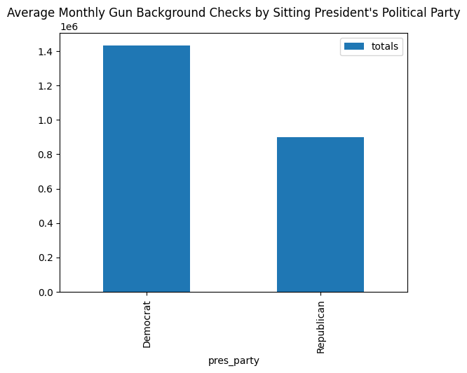

```python
party_results_df.plot(kind='bar', title="Average Monthly Gun Background Checks by Sitting President's Political Party");
```

The last thing regarding this question that I want to look at before moving on is, how the component of time may have played a factor in these results. Since the last nine years of this data included 8 with a sitting Democratic president, if gun background checks were naturally going up as time went on, this would increase the average for Democrats.

So, to get an idea of how gun background checks changed over time, I will plot the total checks done for each month on a line graph.

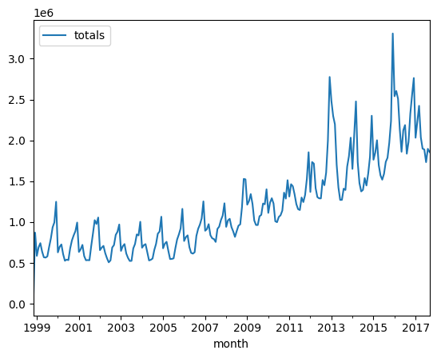

```python
gun_party_df.plot(x='month', y='totals', kind='line');
```

Looking at the graph, it does seem like gun background checks were, while seasonal, holding steady until around 2008. This was an election year, right before a Democratic president took office. Whether it was the incoming President's political party or another factor that caused the gun background checks to increase, is unable to be answered with the data at hand.

### Research Question 2

#### Are there any state demographics that effect the number of background checks being run for guns?

I want to take a look at the relationships between the demographic categories and total gun background checks. Since I don't need to compare every category to each other, I won't use the scatterplot matrix. Instead, I'll run a quick function to plot each category against the 'totals' column.

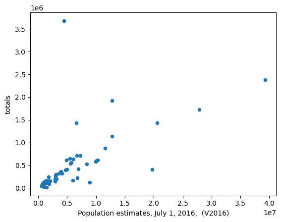

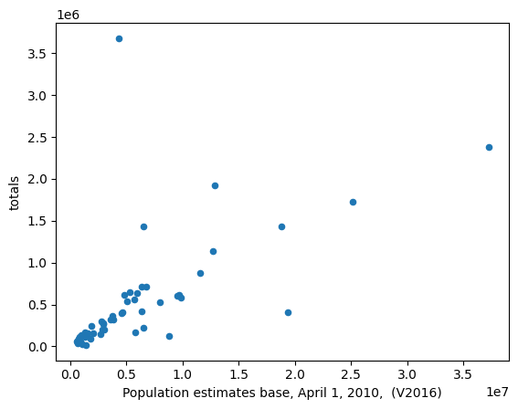

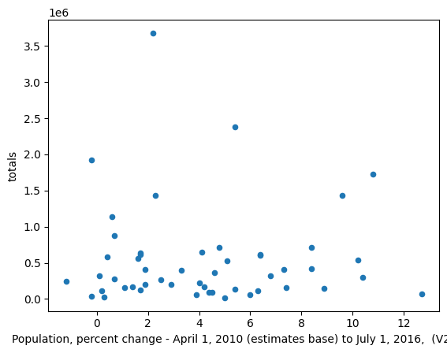

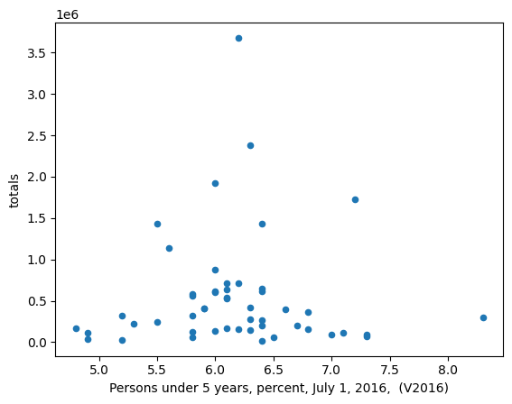

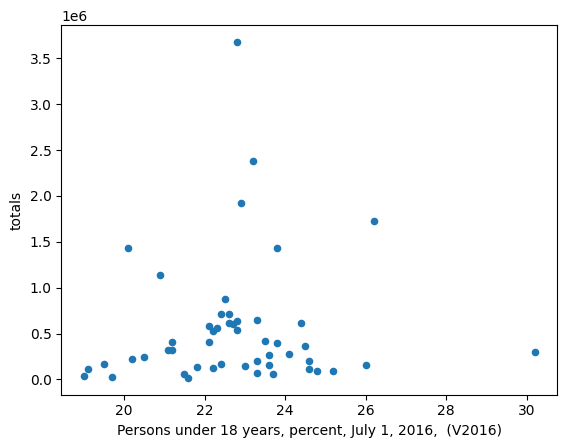

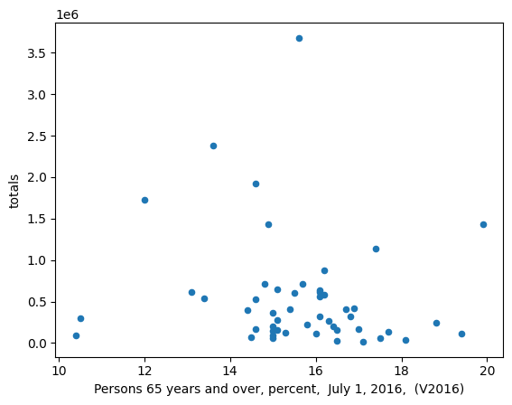

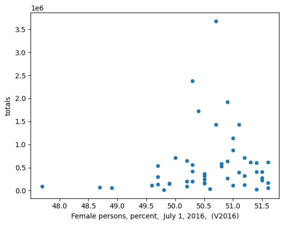

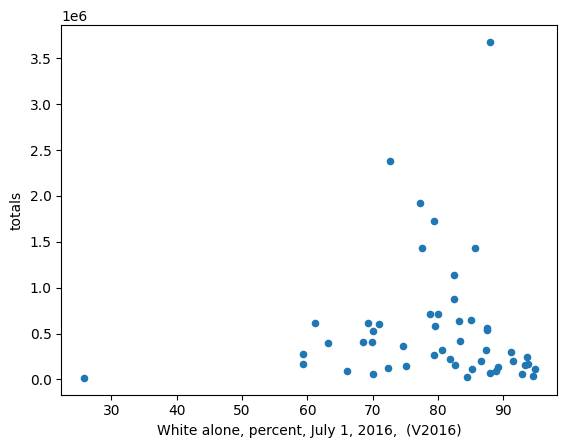

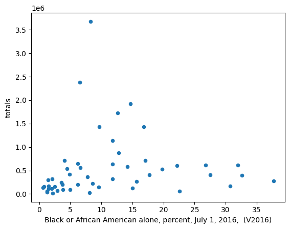

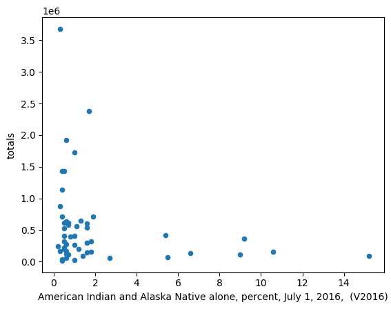

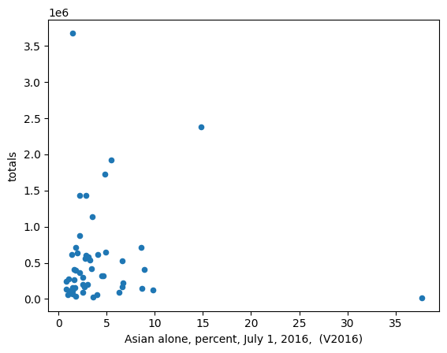

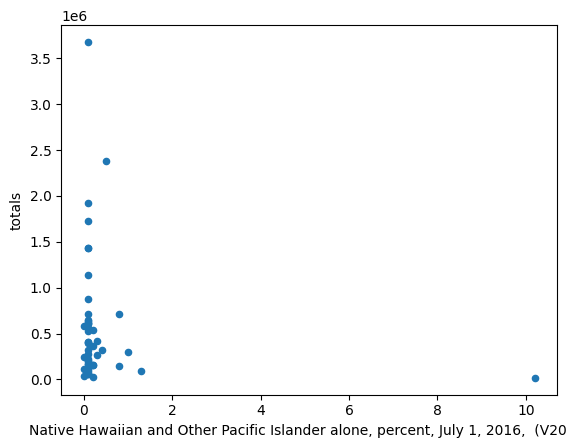

[5 more figures not shown]

```python
for col in gun_census.iloc[:,:-1]:
    gun_census.plot(col,'totals', kind='scatter');
```

The first two graphs show a positive relationship between the total gun background checks and their variables. Intuitively, this makes sense as those variables are both population estimates. It tracks that more people in a state would mean a greater likelihood of more gun background checks.

Also, the last two graphs seem to have a positive relationship as well. These are the Housing Units and Building Permits variables. But my guess would be that these are positively related to the population of the states, as more people would likely mean needing more housing units and more building permits.

But, I can take a look at the relationship of those 4 variables to confirm.

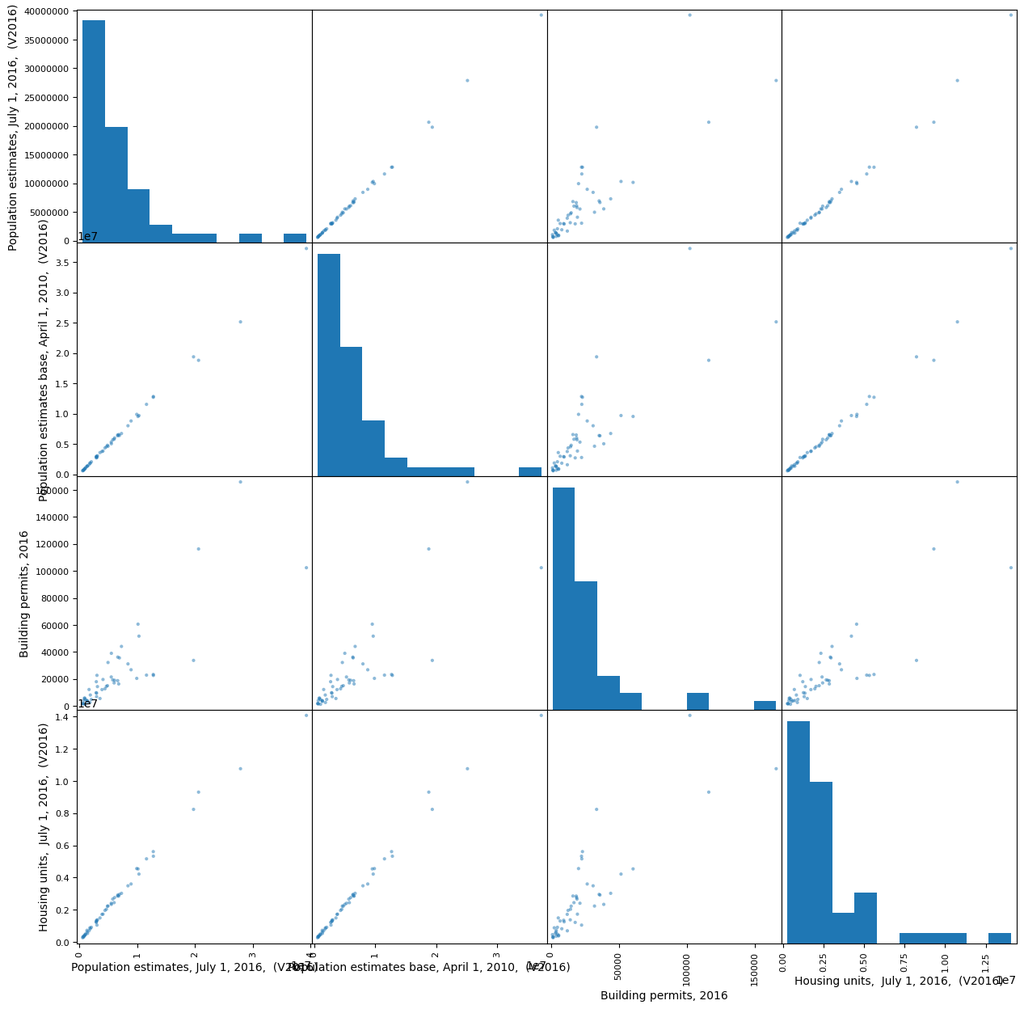

```python
pd.plotting.scatter_matrix(gun_census.iloc[:,[0,1,-2,-3]], figsize=(15,15));
```

While I can't make a concrete statement without running more advanced statistical analysis, it does appear as those variables are related to each other.

Besides those, I don't see any demographics that particulary stand out as having a strong relationship. I did notice though that there may be a few outliers on some of the variables. Looking at the 'Native Hawaiian' variable, there seems to be one state that has a much higher percentage. I can probably guess which, but let's take a look to see.

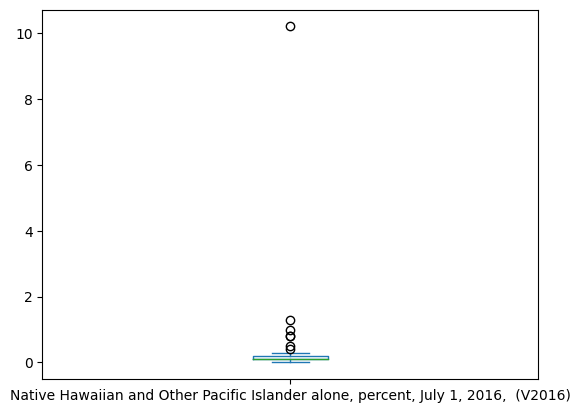

```python
gun_census['Native Hawaiian and Other Pacific Islander alone, percent, July 1, 2016,  (V2016)'].plot(kind='box');
```

While there are a few outliers, there is one that is really skewing the data, let's see who it is.

```python
gun_census.sort_values('Native Hawaiian and Other Pacific Islander alone, percent, July 1, 2016,  (V2016)', ascending=False).head(2)
```

|  | Population estimates, July 1, 2016, (V2016) | Population estimates base, April 1, 2010, (V2016) | Population, percent change - April 1, 2010 (estimates base) to July 1, 2016, (V2016) | Persons under 5 years, percent, July 1, 2016, (V2016) | Persons under 18 years, percent, July 1, 2016, (V2016) | Persons 65 years and over, percent, July 1, 2016, (V2016) | Female persons, percent, July 1, 2016, (V2016) | White alone, percent, July 1, 2016, (V2016) | Black or African American alone, percent, July 1, 2016, (V2016) | American Indian and Alaska Native alone, percent, July 1, 2016, (V2016) | Asian alone, percent, July 1, 2016, (V2016) | Native Hawaiian and Other Pacific Islander alone, percent, July 1, 2016, (V2016) | Two or More Races, percent, July 1, 2016, (V2016) | Hispanic or Latino, percent, July 1, 2016, (V2016) | White alone, not Hispanic or Latino, percent, July 1, 2016, (V2016) | Housing units, July 1, 2016, (V2016) | Building permits, 2016 | totals |
| --- | --- | --- | --- | --- | --- | --- | --- | --- | --- | --- | --- | --- | --- | --- | --- | --- | --- | --- |
| Hawaii | 1428557 | 1360301 | 5.0 | 6.4 | 21.6 | 17.1 | 49.8 | 25.8 | 2.2 | 0.4 | 37.7 | 10.2 | 23.7 | 10.4 | 22.1 | 537114 | 3369 | 16681 |
| Alaska | 741894 | 710249 | 4.5 | 7.3 | 25.2 | 10.4 | 47.7 | 66.1 | 3.8 | 15.2 | 6.3 | 1.3 | 7.3 | 7.0 | 61.2 | 310658 | 1503 | 87647 |

Ahh yes, Hawaii. And it looks like they may be skewing a few other demographics too. Let's remove them for a minute and recheck the relationships to see if anything stands out.

```python
no_hi = gun_census.drop('Hawaii')
no_hi
```

|  | Population estimates, July 1, 2016, (V2016) | Population estimates base, April 1, 2010, (V2016) | Population, percent change - April 1, 2010 (estimates base) to July 1, 2016, (V2016) | Persons under 5 years, percent, July 1, 2016, (V2016) | Persons under 18 years, percent, July 1, 2016, (V2016) | Persons 65 years and over, percent, July 1, 2016, (V2016) | Female persons, percent, July 1, 2016, (V2016) | White alone, percent, July 1, 2016, (V2016) | Black or African American alone, percent, July 1, 2016, (V2016) | American Indian and Alaska Native alone, percent, July 1, 2016, (V2016) | Asian alone, percent, July 1, 2016, (V2016) | Native Hawaiian and Other Pacific Islander alone, percent, July 1, 2016, (V2016) | Two or More Races, percent, July 1, 2016, (V2016) | Hispanic or Latino, percent, July 1, 2016, (V2016) | White alone, not Hispanic or Latino, percent, July 1, 2016, (V2016) | Housing units, July 1, 2016, (V2016) | Building permits, 2016 | totals |
| --- | --- | --- | --- | --- | --- | --- | --- | --- | --- | --- | --- | --- | --- | --- | --- | --- | --- | --- |
| Alabama | 4863300 | 4780131 | 1.7 | 6.0 | 22.6 | 16.1 | 51.6 | 69.3 | 26.8 | 0.7 | 1.4 | 0.1 | 1.6 | 4.2 | 65.8 | 2230185 | 15001 | 616947 |
| Alaska | 741894 | 710249 | 4.5 | 7.3 | 25.2 | 10.4 | 47.7 | 66.1 | 3.8 | 15.2 | 6.3 | 1.3 | 7.3 | 7.0 | 61.2 | 310658 | 1503 | 87647 |
| Arizona | 6931071 | 6392301 | 8.4 | 6.3 | 23.5 | 16.9 | 50.3 | 83.3 | 4.9 | 5.4 | 3.4 | 0.3 | 2.8 | 30.9 | 55.5 | 2961003 | 35578 | 416279 |
| Arkansas | 2988248 | 2916025 | 2.5 | 6.4 | 23.6 | 16.3 | 50.9 | 79.4 | 15.7 | 1.0 | 1.6 | 0.3 | 2.0 | 7.3 | 72.9 | 1354762 | 9474 | 266014 |
| California | 39250017 | 37254522 | 5.4 | 6.3 | 23.2 | 13.6 | 50.3 | 72.7 | 6.5 | 1.7 | 14.8 | 0.5 | 3.8 | 38.9 | 37.7 | 14060525 | 102350 | 2377167 |
| Colorado | 5540545 | 5029324 | 10.2 | 6.1 | 22.8 | 13.4 | 49.7 | 87.5 | 4.5 | 1.6 | 3.3 | 0.2 | 3.0 | 21.3 | 68.6 | 2339118 | 38974 | 540514 |
| Connecticut | 3576452 | 3574114 | 0.1 | 5.2 | 21.1 | 16.1 | 51.2 | 80.6 | 11.8 | 0.5 | 4.7 | 0.1 | 2.3 | 15.7 | 67.7 | 1499116 | 5504 | 317692 |
| Delaware | 952065 | 897936 | 6.0 | 5.8 | 21.5 | 17.5 | 51.6 | 70.1 | 22.6 | 0.6 | 4.0 | 0.1 | 2.6 | 9.2 | 62.9 | 426149 | 5804 | 59430 |
| Florida | 20612439 | 18804592 | 9.6 | 5.5 | 20.1 | 19.9 | 51.1 | 77.6 | 16.8 | 0.5 | 2.9 | 0.1 | 2.1 | 24.9 | 54.9 | 9301642 | 116240 | 1435340 |
| Georgia | 10310371 | 9688680 | 6.4 | 6.4 | 24.4 | 13.1 | 51.3 | 61.2 | 32.0 | 0.5 | 4.1 | 0.1 | 2.1 | 9.4 | 53.4 | 4218776 | 51675 | 612985 |
| Idaho | 1683140 | 1567650 | 7.4 | 6.8 | 26.0 | 15.1 | 49.9 | 93.3 | 0.8 | 1.8 | 1.5 | 0.2 | 2.4 | 12.3 | 82.4 | 700825 | 12165 | 156343 |
| Illinois | 12801539 | 12831574 | -0.2 | 6.0 | 22.9 | 14.6 | 50.9 | 77.2 | 14.7 | 0.6 | 5.5 | 0.1 | 1.9 | 17.0 | 61.7 | 5326970 | 22603 | 1924070 |
| Indiana | 6633053 | 6484136 | 2.3 | 6.4 | 23.8 | 14.9 | 50.7 | 85.6 | 9.7 | 0.4 | 2.2 | 0.1 | 2.0 | 6.8 | 79.6 | 2854546 | 18713 | 1436725 |
| Iowa | 3134693 | 3046869 | 2.9 | 6.4 | 23.3 | 16.4 | 50.3 | 91.4 | 3.7 | 0.5 | 2.5 | 0.1 | 1.8 | 5.8 | 86.2 | 1380162 | 14317 | 202277 |
| Kansas | 2907289 | 2853129 | 1.9 | 6.7 | 24.6 | 15.0 | 50.2 | 86.6 | 6.2 | 1.2 | 3.0 | 0.1 | 2.9 | 11.6 | 76.3 | 1259864 | 9807 | 196548 |
| Kentucky | 4436974 | 4339344 | 2.2 | 6.2 | 22.8 | 15.6 | 50.7 | 88.0 | 8.3 | 0.3 | 1.5 | 0.1 | 1.9 | 3.5 | 85.0 | 1965556 | 12714 | 3676847 |
| Louisiana | 4681666 | 4533479 | 3.3 | 6.6 | 23.8 | 14.4 | 51.1 | 63.2 | 32.6 | 0.8 | 1.8 | 0.1 | 1.6 | 5.0 | 59.0 | 2036975 | 14503 | 391869 |
| Maine | 1331479 | 1328364 | 0.2 | 4.9 | 19.1 | 19.4 | 51.0 | 94.8 | 1.5 | 0.7 | 1.2 | 0.0 | 1.7 | 1.6 | 93.5 | 730705 | 4010 | 111582 |
| Maryland | 6016447 | 5773786 | 4.2 | 6.1 | 22.4 | 14.6 | 51.6 | 59.3 | 30.7 | 0.6 | 6.6 | 0.1 | 2.8 | 9.8 | 51.5 | 2447127 | 17044 | 165367 |
| Massachusetts | 6811779 | 6547813 | 4.0 | 5.3 | 20.2 | 15.8 | 51.5 | 81.8 | 8.6 | 0.5 | 6.7 | 0.1 | 2.3 | 11.5 | 73.0 | 2858026 | 16288 | 226212 |
| Michigan | 9928300 | 9884129 | 0.4 | 5.8 | 22.1 | 16.2 | 50.8 | 79.6 | 14.2 | 0.7 | 3.1 | 0.0 | 2.4 | 5.0 | 75.4 | 4560055 | 20408 | 579605 |
| Minnesota | 5519952 | 5303924 | 4.1 | 6.4 | 23.3 | 15.1 | 50.2 | 85.0 | 6.2 | 1.3 | 4.9 | 0.1 | 2.4 | 5.2 | 80.6 | 2409935 | 21449 | 651599 |
| Mississippi | 2988726 | 2968103 | 0.7 | 6.3 | 24.1 | 15.1 | 51.5 | 59.3 | 37.7 | 0.6 | 1.1 | 0.1 | 1.2 | 3.1 | 56.9 | 1307441 | 6886 | 276161 |
| Missouri | 6093000 | 5988928 | 1.7 | 6.1 | 22.8 | 16.1 | 50.9 | 83.2 | 11.8 | 0.6 | 2.0 | 0.1 | 2.2 | 4.1 | 79.7 | 2760084 | 18997 | 632319 |
| Montana | 1042520 | 989414 | 5.4 | 6.0 | 21.8 | 17.7 | 49.7 | 89.2 | 0.6 | 6.6 | 0.8 | 0.1 | 2.7 | 3.6 | 86.5 | 497756 | 4781 | 136337 |
| Nebraska | 1907116 | 1826334 | 4.4 | 7.0 | 24.8 | 15.0 | 50.2 | 88.9 | 5.0 | 1.4 | 2.5 | 0.1 | 2.1 | 10.7 | 79.6 | 827156 | 8078 | 88663 |
| Nevada | 2940058 | 2700691 | 8.9 | 6.3 | 23.0 | 15.0 | 49.9 | 75.1 | 9.6 | 1.6 | 8.7 | 0.8 | 4.2 | 28.5 | 49.9 | 1221698 | 17952 | 147992 |
| New Hampshire | 1334795 | 1316461 | 1.4 | 4.8 | 19.5 | 17.0 | 50.5 | 93.8 | 1.5 | 0.3 | 2.7 | 0.1 | 1.7 | 3.5 | 90.8 | 625307 | 3796 | 165164 |
| New Jersey | 8944469 | 8791953 | 1.7 | 5.8 | 22.2 | 15.3 | 51.2 | 72.4 | 15.0 | 0.6 | 9.8 | 0.1 | 2.2 | 20.0 | 55.8 | 3604409 | 26793 | 121853 |
| New Mexico | 2081015 | 2059198 | 1.1 | 6.2 | 23.6 | 16.5 | 50.5 | 82.6 | 2.5 | 10.6 | 1.7 | 0.2 | 2.5 | 48.5 | 38.1 | 917568 | 4863 | 161216 |
| New York | 19745289 | 19378110 | 1.9 | 5.9 | 21.2 | 15.4 | 51.4 | 69.9 | 17.7 | 1.0 | 8.9 | 0.1 | 2.5 | 19.0 | 55.8 | 8231687 | 33711 | 404772 |
| North Carolina | 10146788 | 9535688 | 6.4 | 6.0 | 22.7 | 15.5 | 51.4 | 71.0 | 22.2 | 1.6 | 2.9 | 0.1 | 2.2 | 9.2 | 63.5 | 4540498 | 60550 | 601445 |
| North Dakota | 757952 | 672591 | 12.7 | 7.3 | 23.3 | 14.5 | 48.7 | 87.9 | 2.9 | 5.5 | 1.5 | 0.1 | 2.1 | 3.6 | 85.0 | 368624 | 3981 | 72036 |
| Ohio | 11614373 | 11536727 | 0.7 | 6.0 | 22.5 | 16.2 | 51.0 | 82.5 | 12.8 | 0.3 | 2.2 | 0.1 | 2.2 | 3.7 | 79.5 | 5164361 | 22816 | 875724 |
| Oklahoma | 3923561 | 3751615 | 4.6 | 6.8 | 24.5 | 15.0 | 50.5 | 74.6 | 7.8 | 9.2 | 2.2 | 0.2 | 6.1 | 10.3 | 66.2 | 1721045 | 12092 | 364590 |
| Oregon | 4093465 | 3831072 | 6.8 | 5.8 | 21.2 | 16.8 | 50.5 | 87.4 | 2.1 | 1.8 | 4.5 | 0.4 | 3.8 | 12.8 | 76.4 | 1732786 | 19586 | 324708 |
| Pennsylvania | 12784227 | 12702857 | 0.6 | 5.6 | 20.9 | 17.4 | 51.0 | 82.4 | 11.8 | 0.4 | 3.5 | 0.1 | 1.9 | 7.0 | 77.0 | 5612002 | 23303 | 1143220 |
| Rhode Island | 1056426 | 1052940 | 0.3 | 5.2 | 19.7 | 16.5 | 51.4 | 84.4 | 8.1 | 1.0 | 3.6 | 0.2 | 2.7 | 14.9 | 73.3 | 462589 | 1226 | 27758 |
| South Carolina | 4961119 | 4625410 | 7.3 | 5.9 | 22.1 | 16.7 | 51.5 | 68.5 | 27.5 | 0.5 | 1.6 | 0.1 | 1.8 | 5.5 | 63.9 | 2236153 | 32165 | 402978 |
| South Dakota | 865454 | 814195 | 6.3 | 7.1 | 24.6 | 16.0 | 49.6 | 85.2 | 2.0 | 9.0 | 1.5 | 0.1 | 2.3 | 3.7 | 82.5 | 383838 | 5686 | 111921 |
| Tennessee | 6651194 | 6346298 | 4.8 | 6.1 | 22.6 | 15.7 | 51.2 | 78.7 | 17.1 | 0.4 | 1.8 | 0.1 | 1.9 | 5.2 | 74.2 | 2919671 | 36157 | 714774 |
| Texas | 27862596 | 25146100 | 10.8 | 7.2 | 26.2 | 12.0 | 50.4 | 79.4 | 12.6 | 1.0 | 4.8 | 0.1 | 1.9 | 39.1 | 42.6 | 10753629 | 165853 | 1721726 |
| Utah | 3051217 | 2763888 | 10.4 | 8.3 | 30.2 | 10.5 | 49.7 | 91.1 | 1.4 | 1.6 | 2.5 | 1.0 | 2.5 | 13.8 | 78.8 | 1054164 | 22662 | 294907 |
| Vermont | 624594 | 625741 | -0.2 | 4.9 | 19.0 | 18.1 | 50.6 | 94.6 | 1.3 | 0.4 | 1.8 | 0.0 | 1.9 | 1.9 | 93.1 | 329525 | 1771 | 39417 |
| Virginia | 8411808 | 8001041 | 5.1 | 6.1 | 22.2 | 14.6 | 50.8 | 70.0 | 19.8 | 0.5 | 6.6 | 0.1 | 2.9 | 9.1 | 62.4 | 3491054 | 31132 | 528369 |
| Washington | 7288000 | 6724545 | 8.4 | 6.2 | 22.4 | 14.8 | 50.0 | 80.0 | 4.1 | 1.9 | 8.6 | 0.8 | 4.6 | 12.4 | 69.5 | 3025685 | 44077 | 713996 |
| West Virginia | 1831102 | 1853011 | -1.2 | 5.5 | 20.5 | 18.8 | 50.5 | 93.6 | 3.6 | 0.2 | 0.8 | 0.0 | 1.7 | 1.5 | 92.3 | 886640 | 2544 | 242350 |
| Wisconsin | 5778708 | 5687289 | 1.6 | 5.8 | 22.3 | 16.1 | 50.3 | 87.5 | 6.6 | 1.1 | 2.8 | 0.1 | 1.9 | 6.7 | 81.7 | 2668444 | 19274 | 561819 |
| Wyoming | 585501 | 563767 | 3.9 | 6.5 | 23.7 | 15.0 | 48.9 | 92.8 | 1.3 | 2.7 | 1.0 | 0.1 | 2.1 | 10.0 | 84.1 | 270600 | 1727 | 63594 |

Let's rerun the main demographic variable scatterplots again to see if any relationships stand out now.

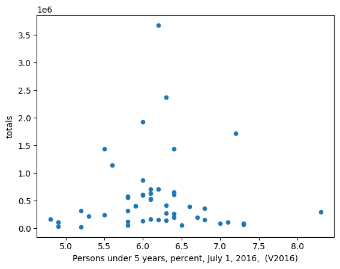

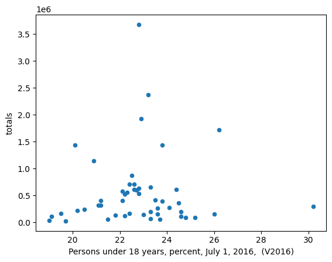

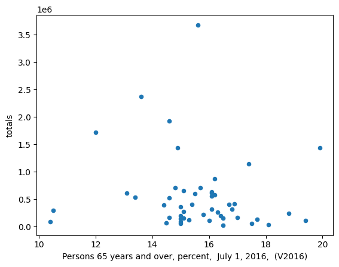

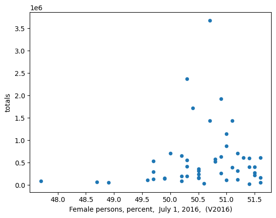

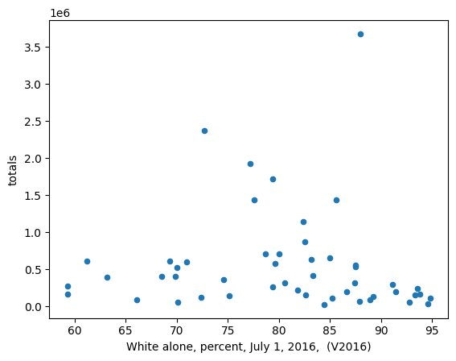

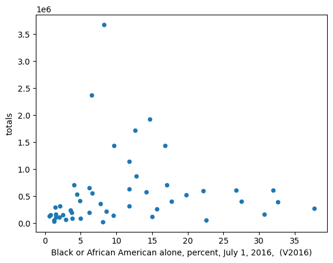

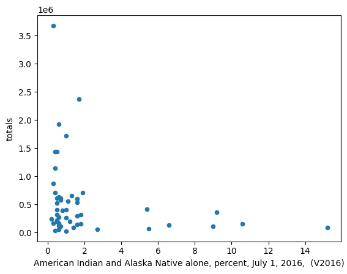

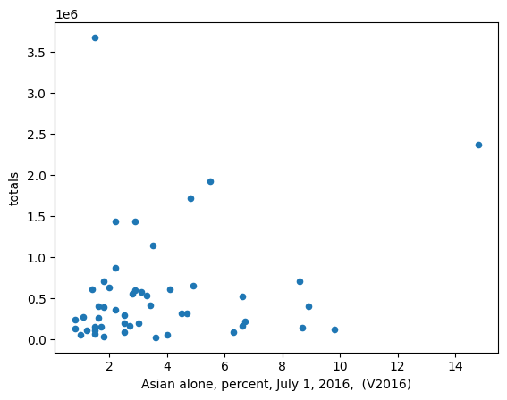

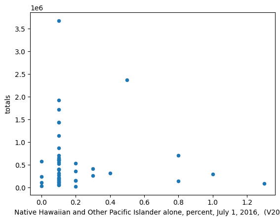

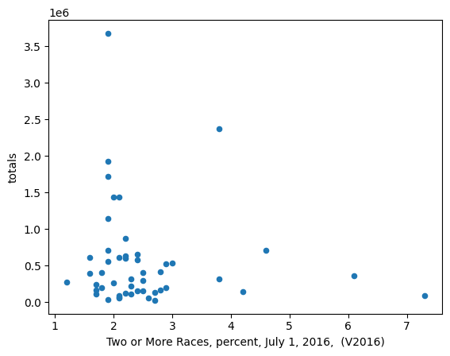

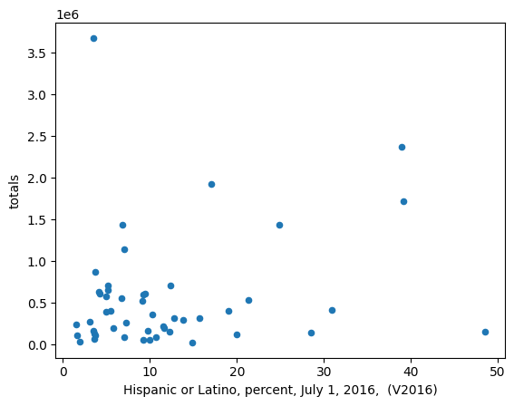

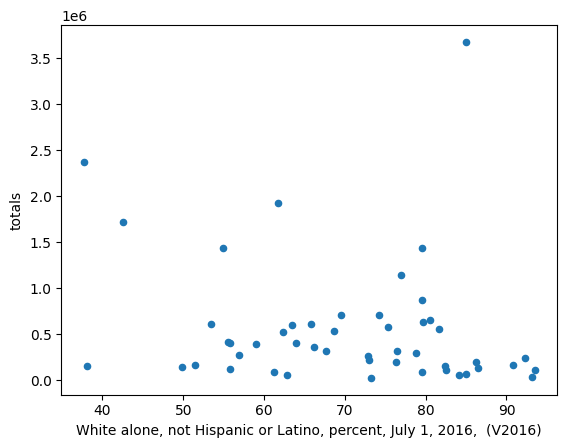

```python
for col in no_hi.iloc[:,3:-3]:
    no_hi.plot(col,'totals', kind='scatter');
```

No specific demographics stand out as having a concrete relationship with the total gun background checks.

One thing I did notice though was that there was another outlier. This time on the total gun background checks. I'll take a look to confirm this.

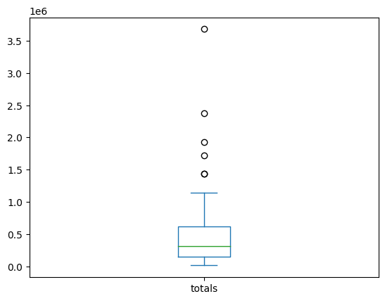

```python
gun_census['totals'].plot(kind='box');
```

```python
gun_census.sort_values('totals', ascending=False).head(6)
```

|  | Population estimates, July 1, 2016, (V2016) | Population estimates base, April 1, 2010, (V2016) | Population, percent change - April 1, 2010 (estimates base) to July 1, 2016, (V2016) | Persons under 5 years, percent, July 1, 2016, (V2016) | Persons under 18 years, percent, July 1, 2016, (V2016) | Persons 65 years and over, percent, July 1, 2016, (V2016) | Female persons, percent, July 1, 2016, (V2016) | White alone, percent, July 1, 2016, (V2016) | Black or African American alone, percent, July 1, 2016, (V2016) | American Indian and Alaska Native alone, percent, July 1, 2016, (V2016) | Asian alone, percent, July 1, 2016, (V2016) | Native Hawaiian and Other Pacific Islander alone, percent, July 1, 2016, (V2016) | Two or More Races, percent, July 1, 2016, (V2016) | Hispanic or Latino, percent, July 1, 2016, (V2016) | White alone, not Hispanic or Latino, percent, July 1, 2016, (V2016) | Housing units, July 1, 2016, (V2016) | Building permits, 2016 | totals |
| --- | --- | --- | --- | --- | --- | --- | --- | --- | --- | --- | --- | --- | --- | --- | --- | --- | --- | --- |
| Kentucky | 4436974 | 4339344 | 2.2 | 6.2 | 22.8 | 15.6 | 50.7 | 88.0 | 8.3 | 0.3 | 1.5 | 0.1 | 1.9 | 3.5 | 85.0 | 1965556 | 12714 | 3676847 |
| California | 39250017 | 37254522 | 5.4 | 6.3 | 23.2 | 13.6 | 50.3 | 72.7 | 6.5 | 1.7 | 14.8 | 0.5 | 3.8 | 38.9 | 37.7 | 14060525 | 102350 | 2377167 |
| Illinois | 12801539 | 12831574 | -0.2 | 6.0 | 22.9 | 14.6 | 50.9 | 77.2 | 14.7 | 0.6 | 5.5 | 0.1 | 1.9 | 17.0 | 61.7 | 5326970 | 22603 | 1924070 |
| Texas | 27862596 | 25146100 | 10.8 | 7.2 | 26.2 | 12.0 | 50.4 | 79.4 | 12.6 | 1.0 | 4.8 | 0.1 | 1.9 | 39.1 | 42.6 | 10753629 | 165853 | 1721726 |
| Indiana | 6633053 | 6484136 | 2.3 | 6.4 | 23.8 | 14.9 | 50.7 | 85.6 | 9.7 | 0.4 | 2.2 | 0.1 | 2.0 | 6.8 | 79.6 | 2854546 | 18713 | 1436725 |
| Florida | 20612439 | 18804592 | 9.6 | 5.5 | 20.1 | 19.9 | 51.1 | 77.6 | 16.8 | 0.5 | 2.9 | 0.1 | 2.1 | 24.9 | 54.9 | 9301642 | 116240 | 1435340 |

Kentucky with over 50% more gun background checks than the next state is a major outlier. Let's take a look at the relationships without Kentucky in there.

```python
no_hi_ky = no_hi.drop('Kentucky')
```

And now I'll rerun those scatter plots one last time.

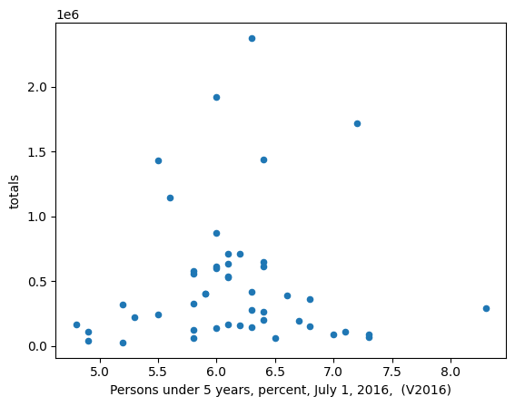

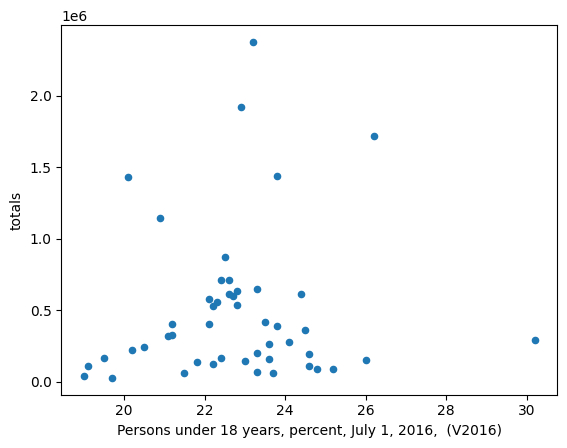

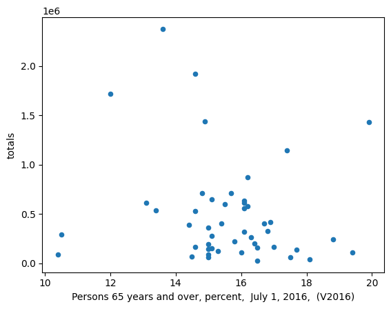

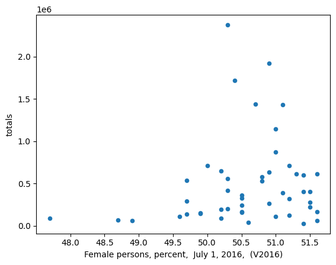

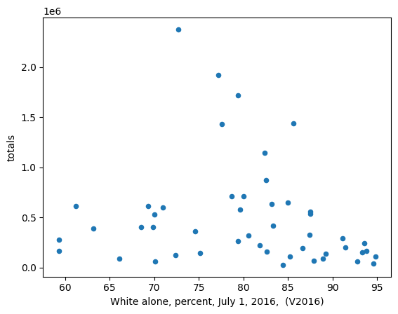

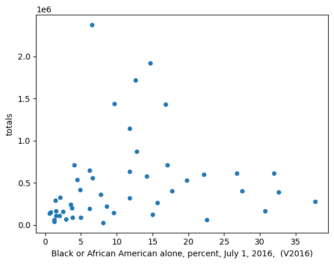

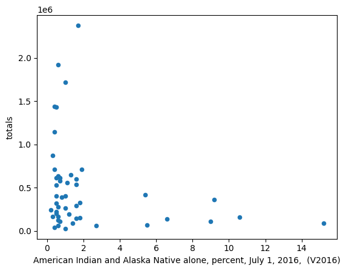

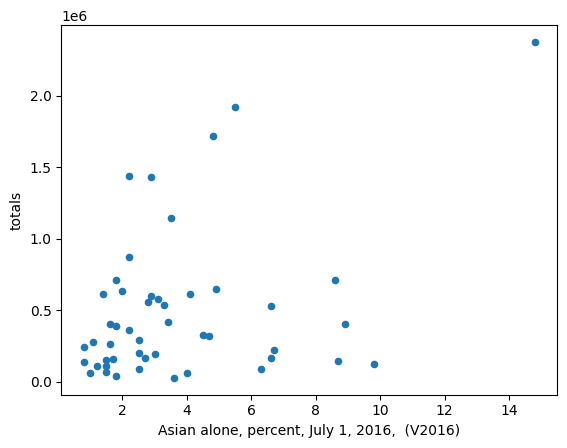

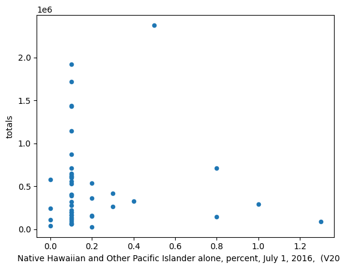

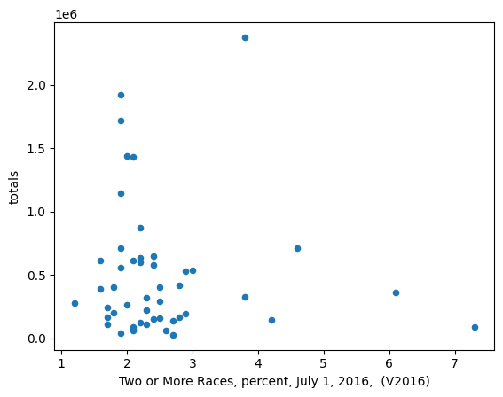

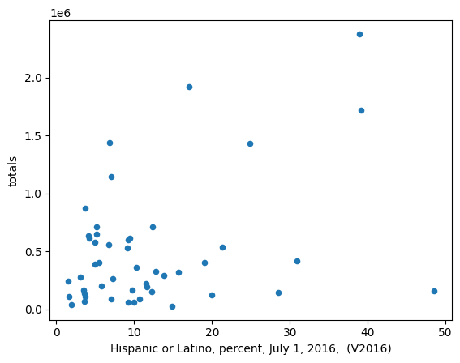

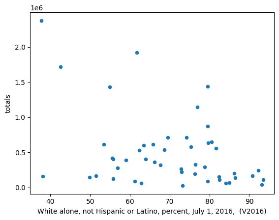

```python
for col in no_hi.iloc[:,3:-3]:
    no_hi_ky.plot(col,'totals', kind='scatter');
```

Looking through the new plots, there still doesn't seem to be any strong relationships between any variables and total gun background checks

## Conclusions

### Question 1

Between November 1998 and September 2017, on average, nearly 60% more gun background checks were run a month when a Democratic president was in office versus a Republican one.

While this is a large difference, it is ultimately an area that has not been fully explored in this research. There are a myriad of other variables that could be in play regarding the relationship. This include things like geopolitical relations, changes in background check requirements, and personal presidential convictions not held specifically by one's political party. All of which does not have data included in this anaylsis, representing one of the limitations of this research.

### Question 2

After looking through the relationships between multiple state demographics and total gun background checks for 2016, there doesn't appear to be any strong relationships.

This topic could be more thoroughly researched by performing true statistical analysis via regressions. The lack of this type of exploration is a limitation of this analysis.